# TARL data

priscila carballo

12/3/2019

## Comparison of dental pathologies between adult male vs. female archaic populations from two southwest Texas archaeological sites.

# Abstract (EDITED)

# Background

Before continuing with analysis of the data collected, it may serve useful to define the pathologies examined as well as briefly discussing the variables used in the dataset.

Firstly, Linear Enamel Hypoplasia, or LEH, is best described as a pathology that occurs when a stress event causes a disruption of ameloblast activity during tooth development and results in irregular prism stuctures called Wilson bands (Witzel et. al, 2008). For this study, a Dino-lite was used to measure the distance of an LEH landmark on a tooth from the CEJ (cementoenamel junction), hence the variable “Distance.” The variable “Duration” describes the length of the LEH landmark/Wilson band, which represents the duration of a stress event that resulted in the LEH formation. Lastly, Age of Insult describes the age an individual was at the time of LEH formation and was found using an LEH calculator that took into account a tooth’s amount of wear and crown size (measured using digital calipers) as well as the LEH’s distance from the CEJ (Cares Enriquez 2018).

Abcesses are best describes as the resorption of alveolar bone such that the apical end of a tooth root is exposed, often due to bacterial infection in a pulp cavity that creates pus and results in necrosis of surrounding tissues and occasionally bone loss (Nagy 2008). Here, we determined an important distinction between abscesses and the pathologically similar cysts and granulomas in that abscesses tend to have a more rounded and porous surface because of the surrounding blood supply, while cysts and granulomas tend to have thin, sharper margins that are the result of a formation of a membranous lining in the cavity (Ogden 2008).

Lastly, Caries are considered to be an infectious disease in which tooth demineralization occurs as a result of cariogenous bacteria collecting and fermenting sugars rich in carbohydrates which lead to cavities on a tooth (Dockall 1997).

Both abscesses and caries were recorded in terms of presence or abscence on an individual in which 0 is absent and 1 is present. For the purposes of the following analyses, LEH age at formation was average for each tooth that was examined to reduce the possible amount of skew in data as a result of multiple LEH measurements on some teeth than others.

# Dataset and Descriptive Statistics

I first imported my data set and assigned it to the vector “TD,” which contained all of the 228 individuals from the Ernest Witte site and the 176 individuals from the Morhiss site with burial numbers and HO numbers. That is, although a larger number of individuals can be found in the initial inventory, only those with associated proveniences and HO numbers were included in the sample size of interest. Secondly, I filtered the TD data into TD1 using the dplyr package. Now the dataset contains only individuals that were considered adults, specifically selecting for the categories “Adult,” “Adult1,” “Adult2,” and “OA” (Older Adult).

```r
f <- "~/Desktop/Repos/tarl-data/TARL Project - Data.xlsx"
library(readxl)
TD <- read_excel(f, sheet = 7, col_names = TRUE)
head(TD)
```

```
## # A tibble: 6 x 20
##   Site  Burial HO    Sex   Age   Abscesses Caries   LEH  RUI1  RUI2   RUC
##   <chr> <chr>  <chr> <chr> <chr>     <dbl>  <dbl> <dbl> <dbl> <dbl> <dbl>
## 1 Erne… 0 or … 3350  F     Adul…         0      0     1 NA       NA NA
## 2 Erne… 4      3108B M     Adul…         0      0     1 NA       NA NA
## 3 Erne… 6      3375  F     Adult         0      0     1 NA       NA NA
## 4 Erne… 7      2551B M     Adult         1      1     1  3.35    NA  3.34
## 5 Erne… 10     3109A F     Adult         0      0     1 NA       NA NA
## 6 Erne… 12     3111A F     Adult         0      0     1 NA       NA NA
## # … with 9 more variables: RLI1 <dbl>, RLI2 <dbl>, RLC <dbl>, LUI1 <dbl>,
## #   LUI2 <dbl>, LUC <dbl>, LLI1 <dbl>, LLI2 <dbl>, LLC <dbl>
```

```r
View(TD)
library(dplyr)
```

```r
library(ggplot2)

TD1 <- filter(TD, Age=="Adult" | Age=="Adult1" | Age=="Adult2" | Age=="OA")
library(skimr)
library(kableExtra)
c <- skim(TD1)
c <-skim_to_wide(TD1)
c %>% select(-type, -missing, -complete, -n, -empty, -n_unique) %>% kable() %>% kable_styling(font_size = 10)
```

| variable | min | max | mean | sd | p0 | p25 | p50 | p75 | p100 | hist |
| --- | --- | --- | --- | --- | --- | --- | --- | --- | --- | --- |
| Age | 2 | 6 | NA | NA | NA | NA | NA | NA | NA | NA |
| Burial | 1 | 24 | NA | NA | NA | NA | NA | NA | NA | NA |
| HO | 3 | 16 | NA | NA | NA | NA | NA | NA | NA | NA |
| Sex | 1 | 1 | NA | NA | NA | NA | NA | NA | NA | NA |
| Site | 7 | 12 | NA | NA | NA | NA | NA | NA | NA | NA |
| Abscesses | NA | NA | 0.099 | 0.3 | 0 | 0 | 0 | 0 | 1 | ▇▁▁▁▁▁▁▁ |
| Caries | NA | NA | 0.12 | 0.33 | 0 | 0 | 0 | 0 | 1 | ▇▁▁▁▁▁▁▁ |
| LEH | NA | NA | 0.39 | 0.49 | 0 | 0 | 0 | 1 | 1 | ▇▁▁▁▁▁▁▅ |
| LLC | NA | NA | 3.93 | 0.45 | 2.83 | 3.61 | 3.97 | 4.27 | 4.84 | ▁▃▂▇▇▇▅▁ |
| LLI1 | NA | NA | 2.52 | 0.51 | 2.08 | 2.14 | 2.4 | 2.77 | 3.19 | ▇▁▁▃▁▁▁▃ |
| LLI2 | NA | NA | 2.67 | 0.79 | 1.28 | 2.32 | 2.63 | 2.87 | 4.62 | ▂▂▅▇▃▁▁▂ |
| LUC | NA | NA | 3.57 | 0.43 | 2.88 | 3.23 | 3.59 | 3.91 | 4.33 | ▆▇▇▅▆▇▅▅ |
| LUI1 | NA | NA | 3.19 | 0.4 | 2.33 | 3 | 3.21 | 3.54 | 3.63 | ▂▁▁▂▃▂▂▇ |
| LUI2 | NA | NA | 3.67 | 0.53 | 2.71 | 3.41 | 3.88 | 4 | 4.47 | ▅▁▂▁▅▇▃▂ |
| RLC | NA | NA | 3.88 | 0.64 | 1.64 | 3.63 | 3.91 | 4.21 | 5.05 | ▁▁▁▁▆▇▃▂ |
| RLI1 | NA | NA | 2.61 | 0.46 | 2.17 | 2.31 | 2.4 | 2.96 | 3.26 | ▃▇▃▁▁▁▃▃ |
| RLI2 | NA | NA | 2.6 | 0.55 | 2.16 | 2.35 | 2.45 | 2.54 | 3.82 | ▅▇▂▁▁▁▁▂ |
| RUC | NA | NA | 3.74 | 0.48 | 2.77 | 3.4 | 3.75 | 4.04 | 5.23 | ▁▅▆▇▅▂▁▁ |
| RUI1 | NA | NA | 3.28 | 0.39 | 2.3 | 3.17 | 3.35 | 3.44 | 3.92 | ▁▁▂▁▂▇▂▁ |
| RUI2 | NA | NA | 3.34 | 0.43 | 2.54 | 3.08 | 3.27 | 3.73 | 3.87 | ▂▁▅▂▅▂▂▇ |

After selecting for our adult subset of the original sample, we can compare the descriptive statistics using the summarytools package. Additional descriptive statistics using the kableExtra and skimr packages were used.

```r
library(summarytools)
s1 <- dfSummary(TD, style = "grid", plain.ascii = FALSE)
s1 %>% summarytools::view()
```

```
## Switching method to 'browser'
```

```
## Output file written: /var/folders/yl/8qkjhz7n6jb8v7vvvpzl0gb40000gn/T//RtmpTmhO4q/filed5667d06c87.html
```

```r
s2 <- dfSummary(TD1, style = "grid", plain.ascii = FALSE)
s2 %>% summarytools::view()
```

```
## Switching method to 'browser'
```

```
## Output file written: /var/folders/yl/8qkjhz7n6jb8v7vvvpzl0gb40000gn/T//RtmpTmhO4q/filed5624854850.html
```

# Analysis of Ernest Witte Data

Firsly, as previously mentioned, this study used a chi-squared statistic to determine whether there is a relation between the presence of LEH and either the presence of abscesses or caries. In other words, the goal was to try to determine whether or not LEH can be considered a predictor for occurence of Abscesses or Caries. the dplyr “filter” function was once again used to select for the Site Ernest Witte. In the following code “EWA” represents Ernest Witte Abscesses, or the total number abscesses of the Ernest Witte Site in all adult individuals. Likewise, EWC represents Ernest Witte Caries, which evaluates the caries in the adult subsample of the Ernest Witte site. Furthermore, other subsamples for further chi square analyses were done such as EWM which represents the male population, EWF, for Ernest Witte females, and EWI for individuals in the Ernest Witte population that were of Indeterminate sex. Other vectors such as EWMA or EWMC represents “Ernest Witte Male Abscesses” and “Ernest Witte Male Caries” - similar letterings were done for females and indeterminate.

```r
EW <- filter(TD1, Site=="Ernest Witte")
View(EW)
table(EW$Abscesses)
```

```
##
##   0   1
## 155  26
```

```r
table(EW$Caries)
```

```
##
##   0   1
## 151  30
```

```r
table(EW$LEH)
```

```
##
##  0  1
## 85 96
```

```r
table(EW$LEH,EW$Caries)
```

```
##
##      0  1
##   0 76  9
##   1 75 21
```

```r
table(EW$LEH,EW$Abscesses)
```

```
##
##      0  1
##   0 69 16
##   1 86 10
```

```r
chisq.test(EW$LEH,EW$Abscesses)
```

```
##
##  Pearson's Chi-squared test with Yates' continuity correction
##
## data:  EW$LEH and EW$Abscesses
## X-squared = 1.9519, df = 1, p-value = 0.1624
```

```r
EWA <-chisq.test(EW$LEH,EW$Abscesses)
EWA$observed
```

```
##       EW$Abscesses
## EW$LEH  0  1
##      0 69 16
##      1 86 10
```

```r
EWA$expected
```

```
##       EW$Abscesses
## EW$LEH        0        1
##      0 72.79006 12.20994
##      1 82.20994 13.79006
```

```r
chisq.test(EW$LEH,EW$Caries)
```

```
##
##  Pearson's Chi-squared test with Yates' continuity correction
##
## data:  EW$LEH and EW$Caries
## X-squared = 3.3773, df = 1, p-value = 0.0661
```

```r
EWC <- chisq.test(EW$LEH,EW$Caries)
EWC$observed
```

```
##       EW$Caries
## EW$LEH  0  1
##      0 76  9
##      1 75 21
```

```r
EWC$expected
```

```
##       EW$Caries
## EW$LEH       0       1
##      0 70.9116 14.0884
##      1 80.0884 15.9116
```

```r
EWC
```

```
##
##  Pearson's Chi-squared test with Yates' continuity correction
##
## data:  EW$LEH and EW$Caries
## X-squared = 3.3773, df = 1, p-value = 0.0661
```

```r
EWM <- filter(EW, Sex=="M")
table(EWM$Abscesses)
```

```
##
##  0  1
## 39 11
```

```r
table(EWM$Caries)
```

```
##
##  0  1
## 43  7
```

```r
chisq.test(EWM$LEH,EWM$Abscesses)
```

```
##
##  Pearson's Chi-squared test with Yates' continuity correction
##
## data:  EWM$LEH and EWM$Abscesses
## X-squared = 0.97294, df = 1, p-value = 0.3239
```

```r
EWMA <-chisq.test(EWM$LEH,EWM$Abscesses)
EWMA$observed
```

```
##        EWM$Abscesses
## EWM$LEH  0  1
##       0 16  7
##       1 23  4
```

```r
EWMA$expected
```

```
##        EWM$Abscesses
## EWM$LEH     0    1
##       0 17.94 5.06
##       1 21.06 5.94
```

```r
chisq.test(EWM$LEH,EWM$Caries)
```

```
##
##  Pearson's Chi-squared test with Yates' continuity correction
##
## data:  EWM$LEH and EWM$Caries
## X-squared = 1.9784, df = 1, p-value = 0.1596
```

```r
EWMC <- chisq.test(EWM$LEH,EWM$Caries)
EWMC$observed
```

```
##        EWM$Caries
## EWM$LEH  0  1
##       0 22  1
##       1 21  6
```

```r
EWMC$expected
```

```
##        EWM$Caries
## EWM$LEH     0    1
##       0 19.78 3.22
##       1 23.22 3.78
```

```r
EWF <- filter(EW, Sex=="F")
table(EWF$Abscesses)
```

```
##
##  0  1
## 43  4
```

```r
table(EWF$Caries)
```

```
##
##  0  1
## 31 16
```

```r
chisq.test(EWF$LEH,EWF$Abscesses)
```

```
##
##  Pearson's Chi-squared test with Yates' continuity correction
##
## data:  EWF$LEH and EWF$Abscesses
## X-squared = 0.023276, df = 1, p-value = 0.8787
```

```r
EWFA <-chisq.test(EWF$LEH,EWF$Abscesses)
EWFA$observed
```

```
##        EWF$Abscesses
## EWF$LEH  0  1
##       0 14  2
##       1 29  2
```

```r
EWFA$expected
```

```
##        EWF$Abscesses
## EWF$LEH       0        1
##       0 14.6383 1.361702
##       1 28.3617 2.638298
```

```r
chisq.test(EWF$LEH,EWF$Caries)
```

```
##
##  Pearson's Chi-squared test with Yates' continuity correction
##
## data:  EWF$LEH and EWF$Caries
## X-squared = 1.8808e-31, df = 1, p-value = 1
```

```r
EWFC <- chisq.test(EWF$LEH,EWF$Caries)
EWFC$observed
```

```
##        EWF$Caries
## EWF$LEH  0  1
##       0 11  5
##       1 20 11
```

```r
EWFC$expected
```

```
##        EWF$Caries
## EWF$LEH        0         1
##       0 10.55319  5.446809
##       1 20.44681 10.553191
```

```r
EWI <- filter(EW, Sex=="I")
table(EWI$Abscesses)
```

```
##
##  0  1
## 60  9
```

```r
table(EWI$Caries)
```

```
##
##  0  1
## 66  3
```

```r
chisq.test(EWI$LEH,EWI$Abscesses)
```

```
##
##  Pearson's Chi-squared test with Yates' continuity correction
##
## data:  EWI$LEH and EWI$Abscesses
## X-squared = 0.15254, df = 1, p-value = 0.6961
```

```r
EWIA <-chisq.test(EWI$LEH,EWI$Abscesses)
EWIA$observed
```

```
##        EWI$Abscesses
## EWI$LEH  0  1
##       0 32  6
##       1 28  3
```

```r
EWIA$expected
```

```
##        EWI$Abscesses
## EWI$LEH        0        1
##       0 33.04348 4.956522
##       1 26.95652 4.043478
```

```r
chisq.test(EWI$LEH,EWI$Caries)
```

```
##
##  Pearson's Chi-squared test with Yates' continuity correction
##
## data:  EWI$LEH and EWI$Caries
## X-squared = 1.4794e-31, df = 1, p-value = 1
```

```r
EWIC <- chisq.test(EWI$LEH,EWI$Caries)
EWIC$observed
```

```
##        EWI$Caries
## EWI$LEH  0  1
##       0 36  2
##       1 30  1
```

```r
EWIC$expected
```

```
##        EWI$Caries
## EWI$LEH        0        1
##       0 36.34783 1.652174
##       1 29.65217 1.347826
```

```r
M <- filter(TD1, Site=="Morhiss")
View(M)
table(M$Abscesses)
```

```
##
##   0   1
## 137   6
```

```r
table(M$Caries)
```

```
##
##   0   1
## 133  10
```

```r
table(M$LEH)
```

```
##
##   0   1
## 114  29
```

```r
table(M$LEH,M$Caries)
```

```
##
##       0   1
##   0 110   4
##   1  23   6
```

```r
table(M$LEH,M$Abscesses)
```

```
##
##       0   1
##   0 113   1
##   1  24   5
```

```r
chisq.test(M$LEH,M$Abscesses)
```

```
##
##  Pearson's Chi-squared test with Yates' continuity correction
##
## data:  M$LEH and M$Abscesses
## X-squared = 11.599, df = 1, p-value = 0.0006598
```

```r
MA <-chisq.test(M$LEH,M$Abscesses)
MA$observed
```

```
##      M$Abscesses
## M$LEH   0   1
##     0 113   1
##     1  24   5
```

```r
MA$expected
```

```
##      M$Abscesses
## M$LEH         0        1
##     0 109.21678 4.783217
##     1  27.78322 1.216783
```

```r
chisq.test(M$LEH,M$Caries)
```

```
##
##  Pearson's Chi-squared test with Yates' continuity correction
##
## data:  M$LEH and M$Caries
## X-squared = 8.0172, df = 1, p-value = 0.004634
```

```r
MC <- chisq.test(M$LEH,M$Caries)
MC$observed
```

```
##      M$Caries
## M$LEH   0   1
##     0 110   4
##     1  23   6
```

```r
MC$expected
```

```
##      M$Caries
## M$LEH         0        1
##     0 106.02797 7.972028
##     1  26.97203 2.027972
```

```r
MC
```

```
##
##  Pearson's Chi-squared test with Yates' continuity correction
##
## data:  M$LEH and M$Caries
## X-squared = 8.0172, df = 1, p-value = 0.004634
```

```r
MM <- filter(M, Sex=="M")
View(MM)
table(MM$Abscesses)
```

```
##
##  0  1
## 12  5
```

```r
table(MM$Caries)
```

```
##
##  0  1
## 15  2
```

```r
table(MM$LEH)
```

```
##
## 0 1
## 9 8
```

```r
table(MM$LEH,MM$Caries)
```

```
##
##     0 1
##   0 9 0
##   1 6 2
```

```r
table(MM$LEH,MM$Abscesses)
```

```
##
##     0 1
##   0 8 1
##   1 4 4
```

```r
chisq.test(MM$LEH,MM$Abscesses)
```

```
##
##  Pearson's Chi-squared test with Yates' continuity correction
##
## data:  MM$LEH and MM$Abscesses
## X-squared = 1.4964, df = 1, p-value = 0.2212
```

```r
MMA <-chisq.test(MM$LEH,MM$Abscesses)
MMA$observed
```

```
##       MM$Abscesses
## MM$LEH 0 1
##      0 8 1
##      1 4 4
```

```r
MMA$expected
```

```
##       MM$Abscesses
## MM$LEH        0        1
##      0 6.352941 2.647059
##      1 5.647059 2.352941
```

```r
chisq.test(MM$LEH,MM$Caries)
```

```
##
##  Pearson's Chi-squared test with Yates' continuity correction
##
## data:  MM$LEH and MM$Caries
## X-squared = 0.7103, df = 1, p-value = 0.3993
```

```r
MMC <- chisq.test(MM$LEH,MM$Caries)
MMC$observed
```

```
##       MM$Caries
## MM$LEH 0 1
##      0 9 0
##      1 6 2
```

```r
MMC$expected
```

```
##       MM$Caries
## MM$LEH        0         1
##      0 7.941176 1.0588235
##      1 7.058824 0.9411765
```

```r
MMC
```

```
##
##  Pearson's Chi-squared test with Yates' continuity correction
##
## data:  MM$LEH and MM$Caries
## X-squared = 0.7103, df = 1, p-value = 0.3993
```

```r
MF <- filter(M, Sex=="F")
View(MF)
table(MF$Abscesses)
```

```
##
##  0
## 12
```

```r
table(MF$Caries)
```

```
##
## 0 1
## 9 3
```

```r
table(MF$LEH)
```

```
##
## 0 1
## 8 4
```

```r
table(MF$LEH,MF$Caries)
```

```
##
##     0 1
##   0 7 1
##   1 2 2
```

```r
table(MF$LEH,MF$Abscesses)
```

```
##
##     0
##   0 8
##   1 4
```

```r
chisq.test(MF$LEH,MF$Caries)
```

```
##
##  Pearson's Chi-squared test with Yates' continuity correction
##
## data:  MF$LEH and MF$Caries
## X-squared = 0.5, df = 1, p-value = 0.4795
```

```r
MFC <- chisq.test(MF$LEH,MF$Caries)
MFC$observed
```

```
##       MF$Caries
## MF$LEH 0 1
##      0 7 1
##      1 2 2
```

```r
MFC$expected
```

```
##       MF$Caries
## MF$LEH 0 1
##      0 6 2
##      1 3 1
```

```r
MFC
```

```
##
##  Pearson's Chi-squared test with Yates' continuity correction
##
## data:  MF$LEH and MF$Caries
## X-squared = 0.5, df = 1, p-value = 0.4795
```

```r
MI <- filter(M, Sex=="I")
View(MI)
table(MI$Abscesses)
```

```
##
##   0   1
## 111   1
```

```r
table(MI$Caries)
```

```
##
##   0   1
## 107   5
```

```r
table(MI$LEH)
```

```
##
##  0  1
## 95 17
```

```r
table(MI$LEH,MI$Caries)
```

```
##
##      0  1
##   0 92  3
##   1 15  2
```

```r
table(MI$LEH,MI$Abscesses)
```

```
##
##      0  1
##   0 95  0
##   1 16  1
```

```r
chisq.test(MI$LEH,MI$Abscesses)
```

```
##
##  Pearson's Chi-squared test with Yates' continuity correction
##
## data:  MI$LEH and MI$Abscesses
## X-squared = 0.95028, df = 1, p-value = 0.3296
```

```r
MIA <-chisq.test(MI$LEH,MI$Abscesses)
MIA$observed
```

```
##       MI$Abscesses
## MI$LEH  0  1
##      0 95  0
##      1 16  1
```

```r
MIA$expected
```

```
##       MI$Abscesses
## MI$LEH        0         1
##      0 94.15179 0.8482143
##      1 16.84821 0.1517857
```

```r
chisq.test(MI$LEH,MI$Caries)
```

```
##
##  Pearson's Chi-squared test with Yates' continuity correction
##
## data:  MI$LEH and MI$Caries
## X-squared = 0.89299, df = 1, p-value = 0.3447
```

```r
MIC <- chisq.test(MI$LEH,MI$Caries)
MIC$observed
```

```
##       MI$Caries
## MI$LEH  0  1
##      0 92  3
##      1 15  2
```

```r
MIC$expected
```

```
##       MI$Caries
## MI$LEH        0         1
##      0 90.75893 4.2410714
##      1 16.24107 0.7589286
```

```r
MIC
```

```
##
##  Pearson's Chi-squared test with Yates' continuity correction
##
## data:  MI$LEH and MI$Caries
## X-squared = 0.89299, df = 1, p-value = 0.3447
```

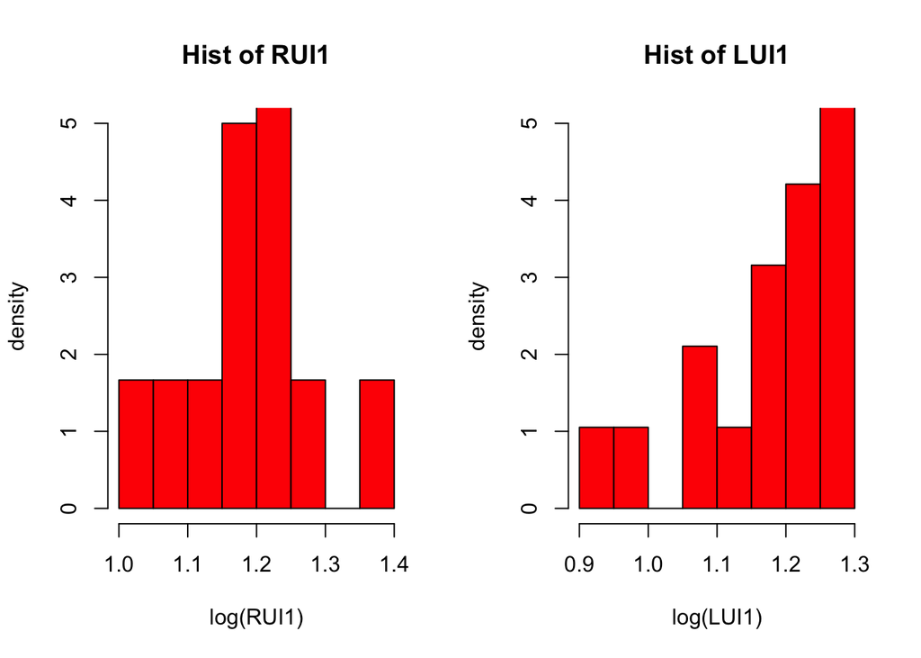

```r
library(dplyr)
EW <- filter(TD1, Site=="Ernest Witte")
EW1 <- filter(EW, LEH=="1")

par(mfrow = c(1, 2))
attach(EW1)
hist(log(RUI1), freq = FALSE, col = "red", main = "Hist of RUI1", xlab = "log(RUI1)",
     ylab = "density", ylim = c(0, 5))


hist(log(LUI1), freq = FALSE, col = "red", main = "Hist of LUI1", xlab = "log(LUI1)",
     ylab = "density", ylim = c(0, 5))
```

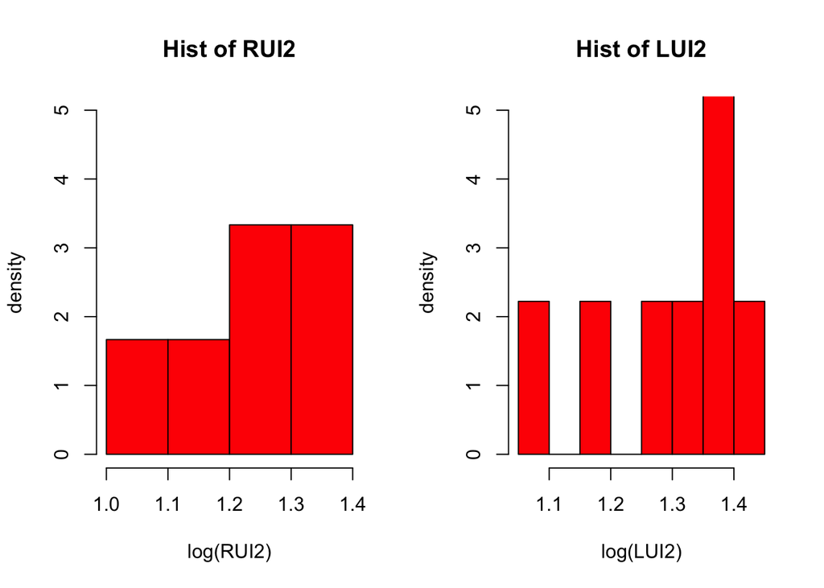

```r
hist(log(RUI2), freq = FALSE, col = "red", main = "Hist of RUI2", xlab = "log(RUI2)",
     ylab = "density", ylim = c(0, 5))


hist(log(LUI2), freq = FALSE, col = "red", main = "Hist of LUI2", xlab = "log(LUI2)",
     ylab = "density", ylim = c(0, 5))
```

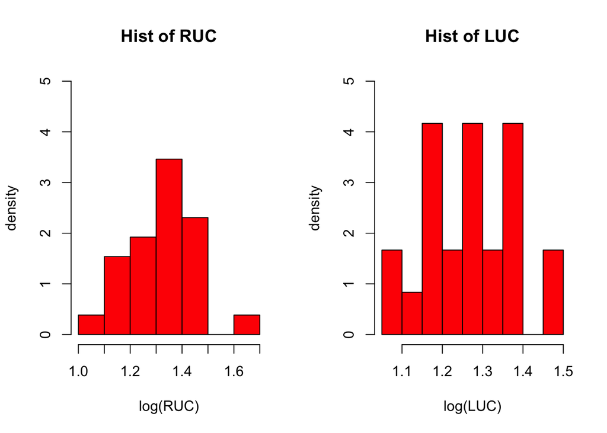

```r
hist(log(RUC), freq = FALSE, col = "red", main = "Hist of RUC", xlab = "log(RUC)",
     ylab = "density", ylim = c(0, 5))


hist(log(LUC), freq = FALSE, col = "red", main = "Hist of LUC", xlab = "log(LUC)",
     ylab = "density", ylim = c(0, 5))
```

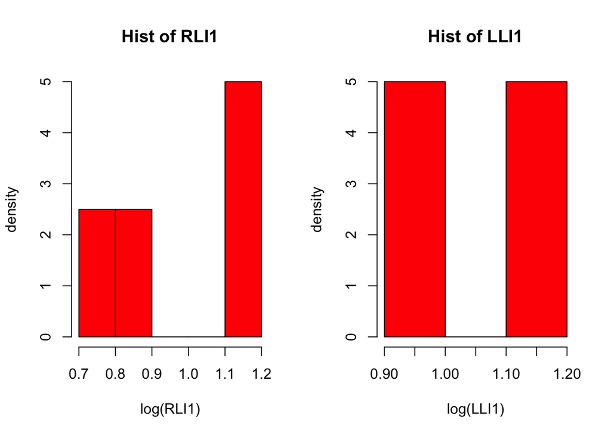

```r
hist(log(RLI1), freq = FALSE, col = "red", main = "Hist of RLI1", xlab = "log(RLI1)",
     ylab = "density", ylim = c(0, 5))


hist(log(LLI1), freq = FALSE, col = "red", main = "Hist of LLI1", xlab = "log(LLI1)",
     ylab = "density", ylim = c(0, 5))
```

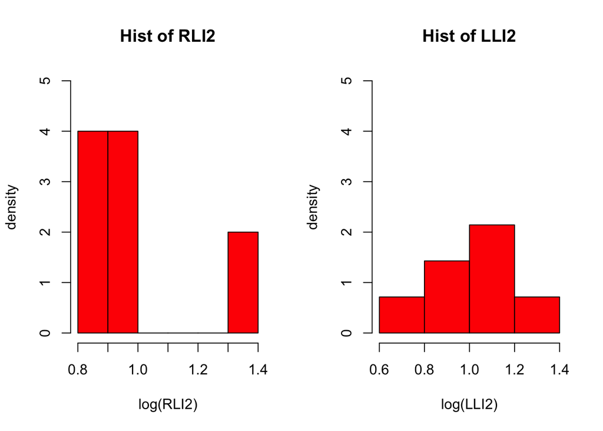

```r
hist(log(RLI2), freq = FALSE, col = "red", main = "Hist of RLI2", xlab = "log(RLI2)",
     ylab = "density", ylim = c(0, 5))


hist(log(LLI2), freq = FALSE, col = "red", main = "Hist of LLI2", xlab = "log(LLI2)",
     ylab = "density", ylim = c(0, 5))
```

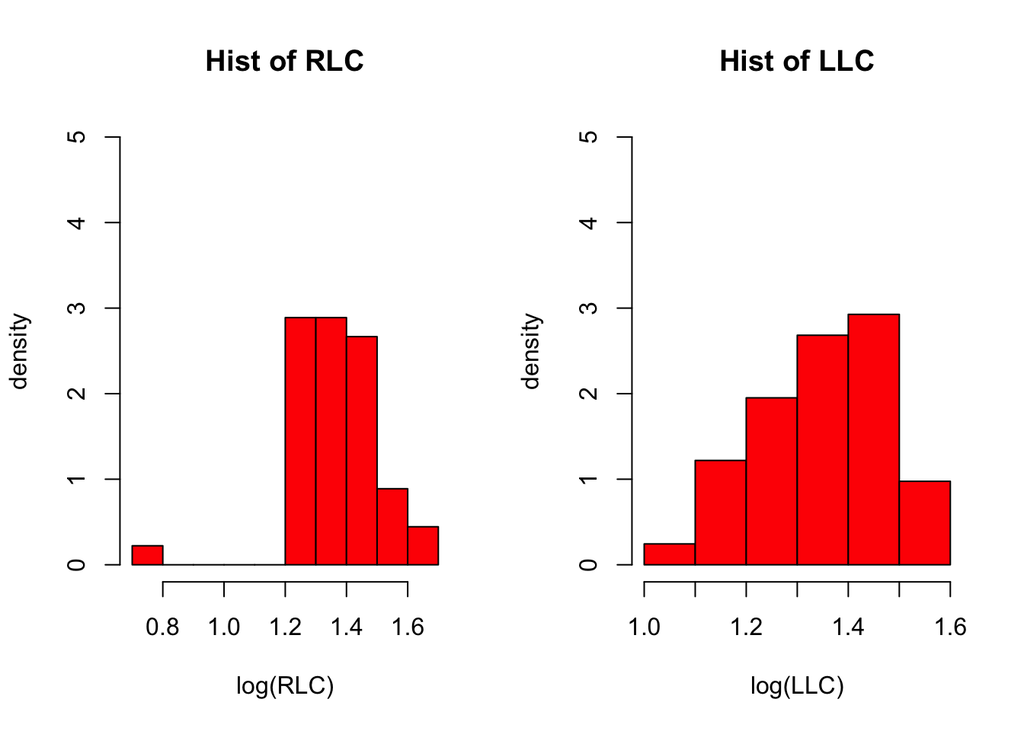

```r
hist(log(RLC), freq = FALSE, col = "red", main = "Hist of RLC", xlab = "log(RLC)",
     ylab = "density", ylim = c(0, 5))



hist(log(LLC), freq = FALSE, col = "red", main = "Hist of LLC", xlab = "log(LLC)",
     ylab = "density", ylim = c(0, 5))
```

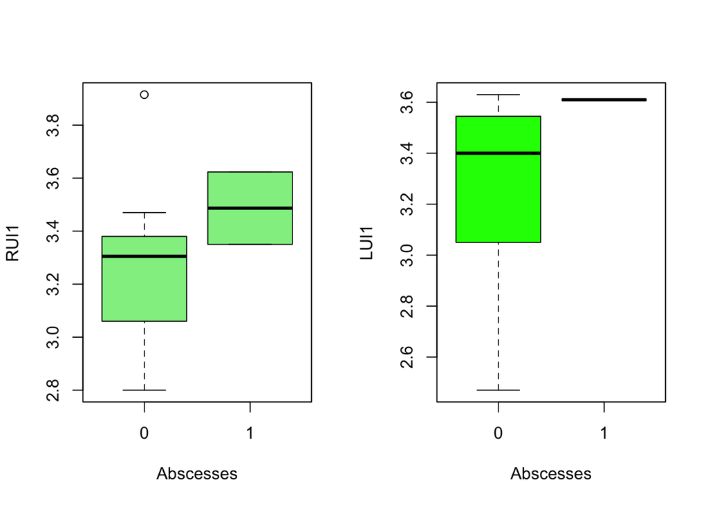

```r
EW1 <- filter(EW, LEH=="1")

par(mfrow = c(1, 2))
plot(as.factor(EW1$Abscesses), EW1$RUI1, xlab = "Abscesses", ylab = "RUI1", col = "lightgreen")
plot(as.factor(EW1$Abscesses), EW1$LUI1, xlab = "Abscesses", ylab = "LUI1", col = "green")
```

```r
logistic <- glm(data = EW1, Abscesses ~ RUI1, family = "binomial")
summary(logistic)
```

```
##
## Call:
## glm(formula = Abscesses ~ RUI1, family = "binomial", data = EW1)
##
## Deviance Residuals:
##     Min       1Q   Median       3Q      Max
## -1.0970  -0.6004  -0.5369  -0.3132   1.9291
##
## Coefficients:
##             Estimate Std. Error z value Pr(>|z|)
## (Intercept)  -10.582     10.228  -1.035    0.301
## RUI1           2.654      2.964   0.895    0.371
##
## (Dispersion parameter for binomial family taken to be 1)
##
##     Null deviance: 10.8135  on 11  degrees of freedom
## Residual deviance:  9.9184  on 10  degrees of freedom
##   (84 observations deleted due to missingness)
## AIC: 13.918
##
## Number of Fisher Scoring iterations: 5
```

```r
logistic1 <- glm(data = EW1, Abscesses ~ LUI1, family = "binomial")
summary(logistic1)
```

```
##
## Call:
## glm(formula = Abscesses ~ LUI1, family = "binomial", data = EW1)
##
## Deviance Residuals:
##      Min        1Q    Median        3Q       Max
## -1.02968  -0.16460  -0.01198  -0.00001   1.67619
##
## Coefficients:
##             Estimate Std. Error z value Pr(>|z|)
## (Intercept)  -139.26     157.71  -0.883    0.377
## LUI1           38.27      43.73   0.875    0.382
##
## (Dispersion parameter for binomial family taken to be 1)
##
##     Null deviance: 7.8353  on 18  degrees of freedom
## Residual deviance: 4.6147  on 17  degrees of freedom
##   (77 observations deleted due to missingness)
## AIC: 8.6147
##
## Number of Fisher Scoring iterations: 10
```

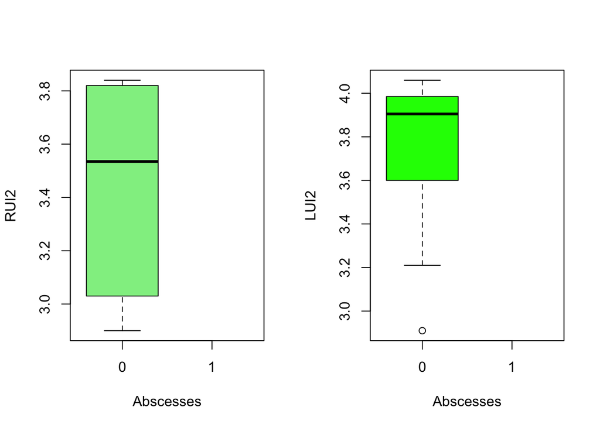

```r
par(mfrow = c(1, 2))
plot(as.factor(EW1$Abscesses), EW1$RUI2, xlab = "Abscesses", ylab = "RUI2", col = "lightgreen")
plot(as.factor(EW1$Abscesses), EW1$LUI2, xlab = "Abscesses", ylab = "LUI2", col = "green")
```

```r
logistic3 <- glm(data = EW1, Abscesses ~ RUI2, family = "binomial")
summary(logistic3)
```

```
##
## Call:
## glm(formula = Abscesses ~ RUI2, family = "binomial", data = EW1)
##
## Deviance Residuals:
##         44          53          54          72          75          82
## -6.547e-06  -6.547e-06  -6.547e-06  -6.547e-06  -6.547e-06  -6.547e-06
##
## Coefficients:
##               Estimate Std. Error z value Pr(>|z|)
## (Intercept) -2.457e+01  5.045e+05       0        1
## RUI2         2.357e-15  1.457e+05       0        1
##
## (Dispersion parameter for binomial family taken to be 1)
##
##     Null deviance: 0.000e+00  on 5  degrees of freedom
## Residual deviance: 2.572e-10  on 4  degrees of freedom
##   (90 observations deleted due to missingness)
## AIC: 4
##
## Number of Fisher Scoring iterations: 23
```

```r
logistic4 <- glm(data = EW1, Abscesses ~ LUI2, family = "binomial")
summary(logistic4)
```

```
##
## Call:
## glm(formula = Abscesses ~ LUI2, family = "binomial", data = EW1)
##
## Deviance Residuals:
##        Min          1Q      Median          3Q         Max
## -6.547e-06  -6.547e-06  -6.547e-06  -6.547e-06  -6.547e-06
##
## Coefficients:
##               Estimate Std. Error z value Pr(>|z|)
## (Intercept) -2.457e+01  4.300e+05       0        1
## LUI2        -7.240e-15  1.152e+05       0        1
##
## (Dispersion parameter for binomial family taken to be 1)
##
##     Null deviance: 0.000e+00  on 8  degrees of freedom
## Residual deviance: 3.858e-10  on 7  degrees of freedom
##   (87 observations deleted due to missingness)
## AIC: 4
##
## Number of Fisher Scoring iterations: 23
```

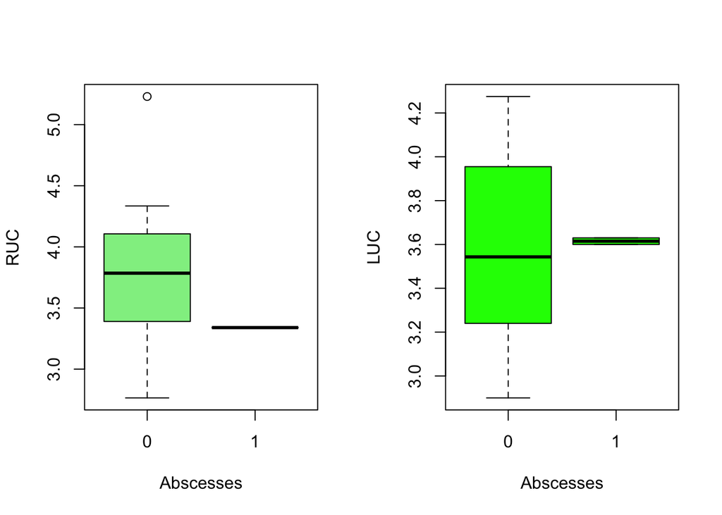

```r
par(mfrow = c(1, 2))
plot(as.factor(EW1$Abscesses), EW1$RUC, xlab = "Abscesses", ylab = "RUC", col = "lightgreen")
plot(as.factor(EW1$Abscesses), EW1$LUC, xlab = "Abscesses", ylab = "LUC", col = "green")
```

```r
logistic5 <- glm(data = EW1, Abscesses ~ RUC, family = "binomial")
summary(logistic5)
```

```
##
## Call:
## glm(formula = Abscesses ~ RUC, family = "binomial", data = EW1)
##
## Deviance Residuals:
##     Min       1Q   Median       3Q      Max
## -0.6290  -0.3249  -0.2112  -0.1389   2.3847
##
## Coefficients:
##             Estimate Std. Error z value Pr(>|z|)
## (Intercept)    4.556      8.952   0.509    0.611
## RUC           -2.197      2.645  -0.831    0.406
##
## (Dispersion parameter for binomial family taken to be 1)
##
##     Null deviance: 8.4772  on 25  degrees of freedom
## Residual deviance: 7.6489  on 24  degrees of freedom
##   (70 observations deleted due to missingness)
## AIC: 11.649
##
## Number of Fisher Scoring iterations: 7
```

```r
logistic6 <- glm(data = EW1, Abscesses ~ LUC, family = "binomial")
summary(logistic6)
```

```
##
## Call:
## glm(formula = Abscesses ~ LUC, family = "binomial", data = EW1)
##
## Deviance Residuals:
##     Min       1Q   Median       3Q      Max
## -0.4611  -0.4373  -0.4079  -0.3939   2.2283
##
## Coefficients:
##             Estimate Std. Error z value Pr(>|z|)
## (Intercept)  -3.5019     6.9461  -0.504    0.614
## LUC           0.3074     1.9126   0.161    0.872
##
## (Dispersion parameter for binomial family taken to be 1)
##
##     Null deviance: 13.768  on 23  degrees of freedom
## Residual deviance: 13.742  on 22  degrees of freedom
##   (72 observations deleted due to missingness)
## AIC: 17.742
##
## Number of Fisher Scoring iterations: 5
```

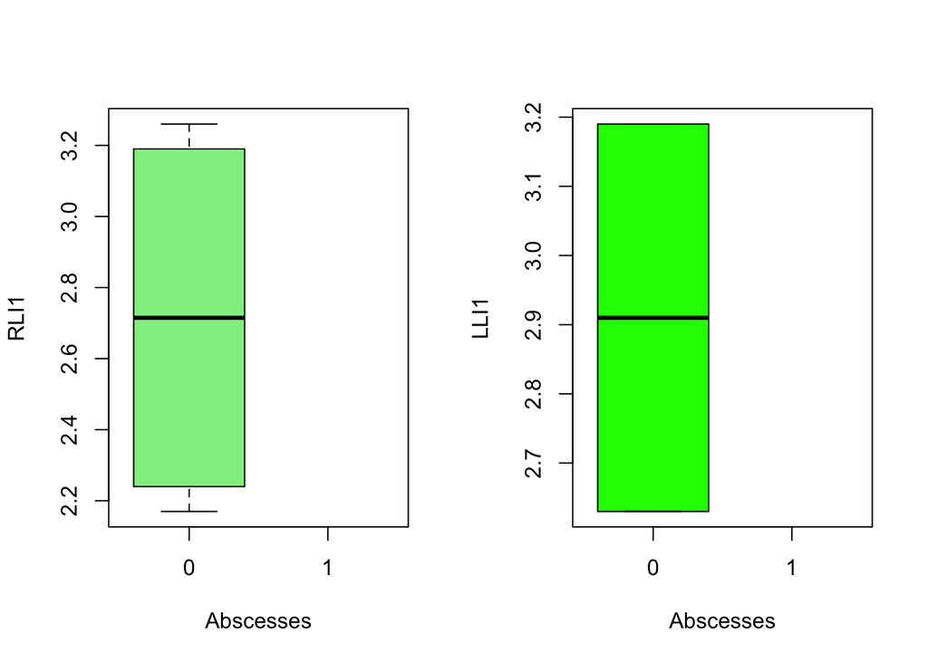

```r
par(mfrow = c(1, 2))
plot(as.factor(EW1$Abscesses), EW1$RLI1, xlab = "Abscesses", ylab = "RLI1", col = "lightgreen")
plot(as.factor(EW1$Abscesses), EW1$LLI1, xlab = "Abscesses", ylab = "LLI1", col = "green")
```

```r
logistic7 <- glm(data = EW1, Abscesses ~ RLI1, family = "binomial")
summary(logistic7)
```

```
##
## Call:
## glm(formula = Abscesses ~ RLI1, family = "binomial", data = EW1)
##
## Deviance Residuals:
##         40          81          83          86
## -1.079e-05  -1.079e-05  -1.079e-05  -1.079e-05
##
## Coefficients:
##               Estimate Std. Error z value Pr(>|z|)
## (Intercept) -2.357e+01  2.282e+05       0        1
## RLI1        -1.331e-14  8.275e+04       0        1
##
## (Dispersion parameter for binomial family taken to be 1)
##
##     Null deviance: 0.000e+00  on 3  degrees of freedom
## Residual deviance: 4.661e-10  on 2  degrees of freedom
##   (92 observations deleted due to missingness)
## AIC: 4
##
## Number of Fisher Scoring iterations: 22
```

```r
logistic8 <- glm(data = EW1, Abscesses ~ LLI1, family = "binomial")
summary(logistic8)
```

```
##
## Call:
## glm(formula = Abscesses ~ LLI1, family = "binomial", data = EW1)
##
## Deviance Residuals:
## [1]  0  0
##
## Coefficients:
##               Estimate Std. Error z value Pr(>|z|)
## (Intercept) -2.357e+01  5.867e+05       0        1
## LLI1         3.264e-14  2.007e+05       0        1
##
## (Dispersion parameter for binomial family taken to be 1)
##
##     Null deviance: 0.0000e+00  on 1  degrees of freedom
## Residual deviance: 2.3305e-10  on 0  degrees of freedom
##   (94 observations deleted due to missingness)
## AIC: 4
##
## Number of Fisher Scoring iterations: 22
```

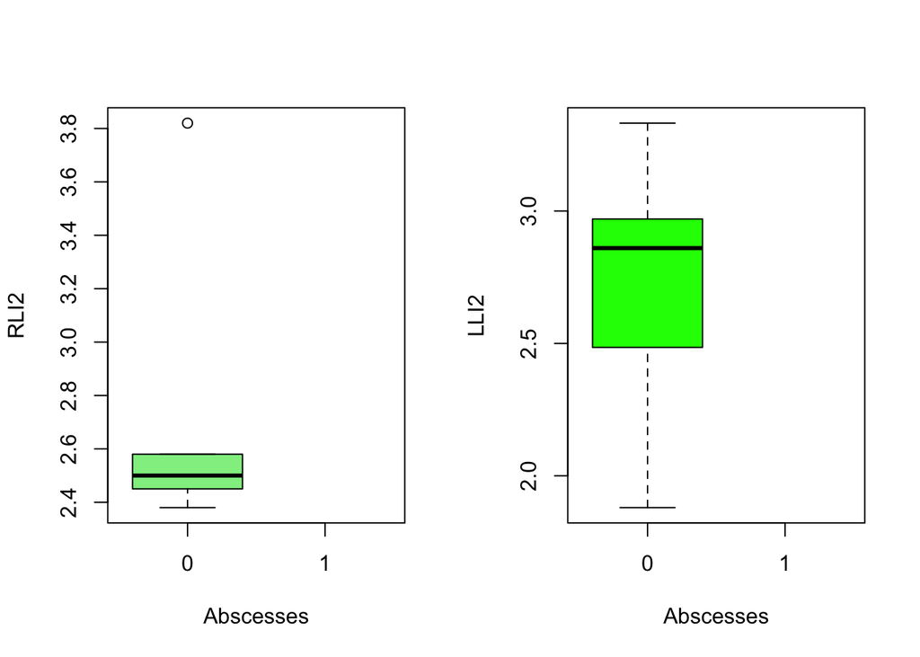

```r
par(mfrow = c(1, 2))
plot(as.factor(EW1$Abscesses), EW1$RLI2, xlab = "Abscesses", ylab = "RLI2", col = "lightgreen")
plot(as.factor(EW1$Abscesses), EW1$LLI2, xlab = "Abscesses", ylab = "LLI2", col = "green")
```

```r
logistic9 <- glm(data = EW1, Abscesses ~ RLI2, family = "binomial")
summary(logistic9)
```

```
##
## Call:
## glm(formula = Abscesses ~ RLI2, family = "binomial", data = EW1)
##
## Deviance Residuals:
##         36          40          58          83          86
## -6.547e-06  -6.547e-06  -6.547e-06  -6.547e-06  -6.547e-06
##
## Coefficients:
##               Estimate Std. Error z value Pr(>|z|)
## (Intercept) -2.457e+01  3.031e+05       0        1
## RLI2         2.392e-14  1.083e+05       0        1
##
## (Dispersion parameter for binomial family taken to be 1)
##
##     Null deviance: 0.0000e+00  on 4  degrees of freedom
## Residual deviance: 2.1434e-10  on 3  degrees of freedom
##   (91 observations deleted due to missingness)
## AIC: 4
##
## Number of Fisher Scoring iterations: 23
```

```r
logistic10 <- glm(data = EW1, Abscesses ~ LLI2, family = "binomial")
summary(logistic10)
```

```
##
## Call:
## glm(formula = Abscesses ~ LLI2, family = "binomial", data = EW1)
##
## Deviance Residuals:
##         40          43          45          46          81          83
## -6.547e-06  -6.547e-06  -6.547e-06  -6.547e-06  -6.547e-06  -6.547e-06
##         84
## -6.547e-06
##
## Coefficients:
##               Estimate Std. Error z value Pr(>|z|)
## (Intercept) -2.457e+01  3.033e+05       0        1
## LLI2         2.575e-14  1.104e+05       0        1
##
## (Dispersion parameter for binomial family taken to be 1)
##
##     Null deviance: 0.0000e+00  on 6  degrees of freedom
## Residual deviance: 3.0007e-10  on 5  degrees of freedom
##   (89 observations deleted due to missingness)
## AIC: 4
##
## Number of Fisher Scoring iterations: 23
```

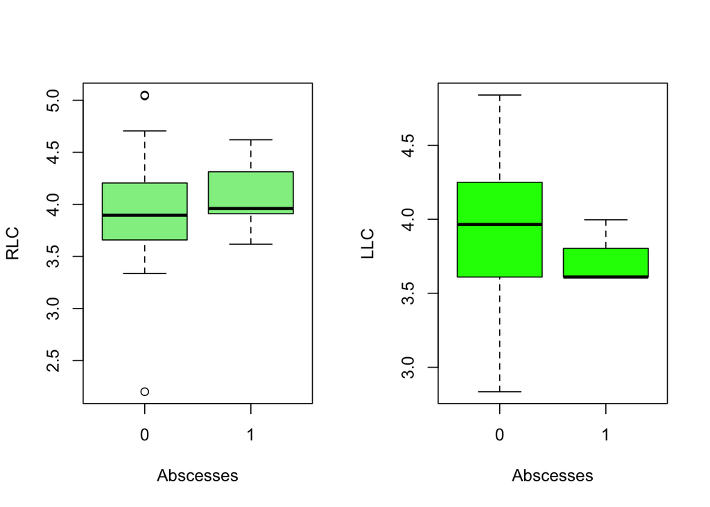

```r
par(mfrow = c(1, 2))
plot(as.factor(EW1$Abscesses), EW1$RLC, xlab = "Abscesses", ylab = "RLC", col = "lightgreen")
plot(as.factor(EW1$Abscesses), EW1$LLC, xlab = "Abscesses", ylab = "LLC", col = "green")
```

```r
logistic11 <- glm(data = EW1, Abscesses ~ RLC, family = "binomial")
summary(logistic9)
```

```
##
## Call:
## glm(formula = Abscesses ~ RLI2, family = "binomial", data = EW1)
##
## Deviance Residuals:
##         36          40          58          83          86
## -6.547e-06  -6.547e-06  -6.547e-06  -6.547e-06  -6.547e-06
##
## Coefficients:
##               Estimate Std. Error z value Pr(>|z|)
## (Intercept) -2.457e+01  3.031e+05       0        1
## RLI2         2.392e-14  1.083e+05       0        1
##
## (Dispersion parameter for binomial family taken to be 1)
##
##     Null deviance: 0.0000e+00  on 4  degrees of freedom
## Residual deviance: 2.1434e-10  on 3  degrees of freedom
##   (91 observations deleted due to missingness)
## AIC: 4
##
## Number of Fisher Scoring iterations: 23
```

```r
logistic12 <- glm(data = EW1, Abscesses ~ LLC, family = "binomial")
summary(logistic10)
```

```
##
## Call:
## glm(formula = Abscesses ~ LLI2, family = "binomial", data = EW1)
##
## Deviance Residuals:
##         40          43          45          46          81          83
## -6.547e-06  -6.547e-06  -6.547e-06  -6.547e-06  -6.547e-06  -6.547e-06
##         84
## -6.547e-06
##
## Coefficients:
##               Estimate Std. Error z value Pr(>|z|)
## (Intercept) -2.457e+01  3.033e+05       0        1
## LLI2         2.575e-14  1.104e+05       0        1
##
## (Dispersion parameter for binomial family taken to be 1)
##
##     Null deviance: 0.0000e+00  on 6  degrees of freedom
## Residual deviance: 3.0007e-10  on 5  degrees of freedom
##   (89 observations deleted due to missingness)
## AIC: 4
##
## Number of Fisher Scoring iterations: 23
```

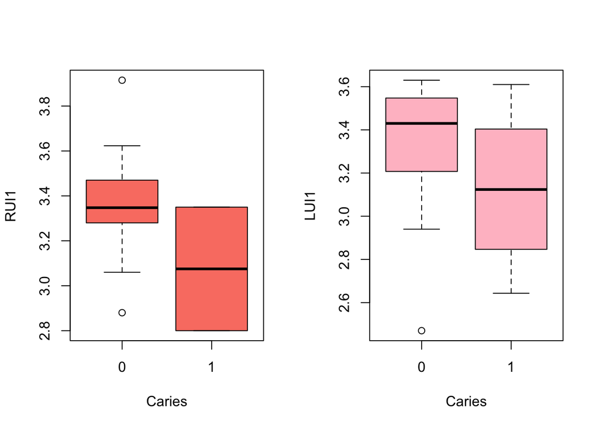

```r
EW1 <- filter(EW, LEH=="1")

par(mfrow = c(1, 2))
plot(as.factor(EW1$Caries), EW1$RUI1, xlab = "Caries", ylab = "RUI1", col = "salmon")
plot(as.factor(EW1$Caries), EW1$LUI1, xlab = "Caries", ylab = "LUI1", col = "pink")
```

```r
logistic <- glm(data = EW1, Caries ~ RUI1, family = "binomial")
summary(logistic)
```

```
##
## Call:
## glm(formula = Caries ~ RUI1, family = "binomial", data = EW1)
##
## Deviance Residuals:
##     Min       1Q   Median       3Q      Max
## -1.0601  -0.5284  -0.4465  -0.2482   2.1246
##
## Coefficients:
##             Estimate Std. Error z value Pr(>|z|)
## (Intercept)   11.140     10.412   1.070    0.285
## RUI1          -3.966      3.308  -1.199    0.231
##
## (Dispersion parameter for binomial family taken to be 1)
##
##     Null deviance: 10.8135  on 11  degrees of freedom
## Residual deviance:  9.0702  on 10  degrees of freedom
##   (84 observations deleted due to missingness)
## AIC: 13.07
##
## Number of Fisher Scoring iterations: 5
```

```r
logistic1 <- glm(data = EW1, Caries ~ LUI1, family = "binomial")
summary(logistic1)
```

```
##
## Call:
## glm(formula = Caries ~ LUI1, family = "binomial", data = EW1)
##
## Deviance Residuals:
##     Min       1Q   Median       3Q      Max
## -1.1810  -0.6538  -0.5579  -0.5072   2.0509
##
## Coefficients:
##             Estimate Std. Error z value Pr(>|z|)
## (Intercept)    4.301      5.252   0.819    0.413
## LUI1          -1.738      1.636  -1.062    0.288
##
## (Dispersion parameter for binomial family taken to be 1)
##
##     Null deviance: 19.557  on 18  degrees of freedom
## Residual deviance: 18.420  on 17  degrees of freedom
##   (77 observations deleted due to missingness)
## AIC: 22.42
##
## Number of Fisher Scoring iterations: 4
```

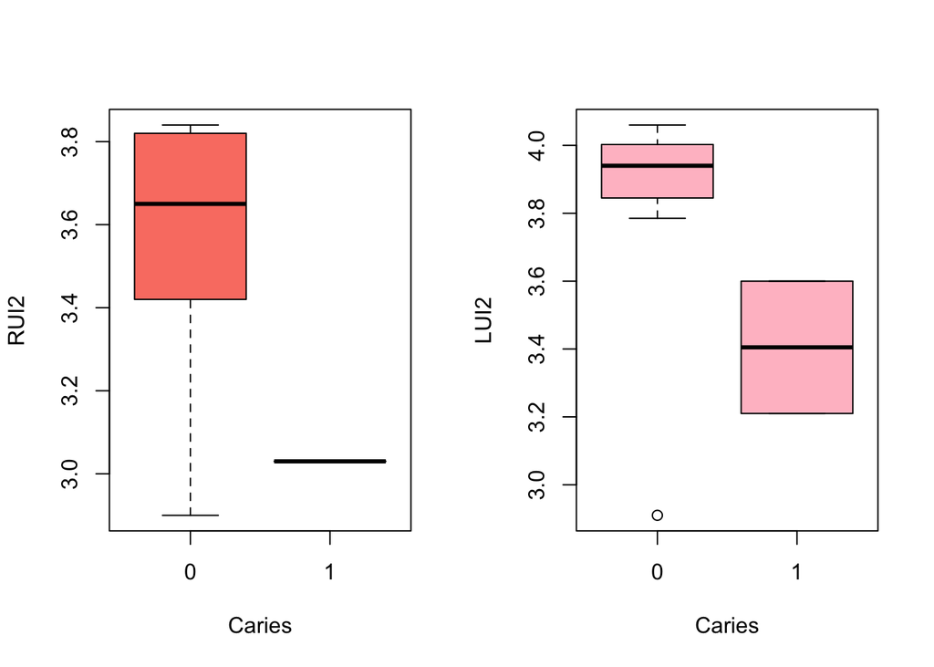

```r
par(mfrow = c(1, 2))
plot(as.factor(EW1$Caries), EW1$RUI2, xlab = "Caries", ylab = "RUI2", col = "salmon")
plot(as.factor(EW1$Caries), EW1$LUI2, xlab = "Caries", ylab = "LUI2", col = "pink")
```

```r
logistic3 <- glm(data = EW1, Caries ~ RUI2, family = "binomial")
summary(logistic3)
```

```
##
## Call:
## glm(formula = Caries ~ RUI2, family = "binomial", data = EW1)
##
## Deviance Residuals:
##      44       53       54       72       75       82
## -0.4050  -0.1573   1.4317  -1.1970  -0.1499  -0.2359
##
## Coefficients:
##             Estimate Std. Error z value Pr(>|z|)
## (Intercept)   14.018     15.704   0.893    0.372
## RUI2          -4.818      5.079  -0.949    0.343
##
## (Dispersion parameter for binomial family taken to be 1)
##
##     Null deviance: 5.4067  on 5  degrees of freedom
## Residual deviance: 3.7494  on 4  degrees of freedom
##   (90 observations deleted due to missingness)
## AIC: 7.7494
##
## Number of Fisher Scoring iterations: 6
```

```r
logistic4 <- glm(data = EW1, Caries ~ LUI2, family = "binomial")
summary(logistic4)
```

```
##
## Call:
## glm(formula = Caries ~ LUI2, family = "binomial", data = EW1)
##
## Deviance Residuals:
##     Min       1Q   Median       3Q      Max
## -1.4229  -0.5122  -0.4655  -0.4251   1.7065
##
## Coefficients:
##             Estimate Std. Error z value Pr(>|z|)
## (Intercept)    7.947      7.683   1.034    0.301
## LUI2          -2.538      2.147  -1.183    0.237
##
## (Dispersion parameter for binomial family taken to be 1)
##
##     Null deviance: 9.5347  on 8  degrees of freedom
## Residual deviance: 7.9823  on 7  degrees of freedom
##   (87 observations deleted due to missingness)
## AIC: 11.982
##
## Number of Fisher Scoring iterations: 4
```

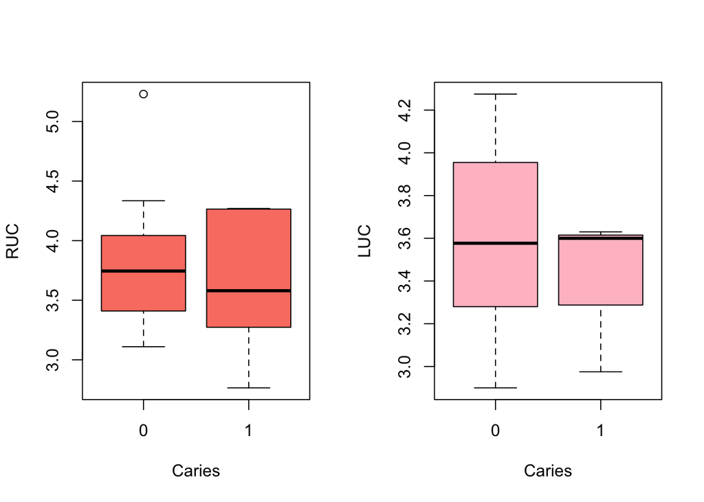

```r
par(mfrow = c(1, 2))
plot(as.factor(EW1$Caries), EW1$RUC, xlab = "Caries", ylab = "RUC", col = "salmon")
plot(as.factor(EW1$Caries), EW1$LUC, xlab = "Caries", ylab = "LUC", col = "pink")
```

```r
logistic5 <- glm(data = EW1, Caries ~ RUC, family = "binomial")
summary(logistic5)
```

```
##
## Call:
## glm(formula = Caries ~ RUC, family = "binomial", data = EW1)
##
## Deviance Residuals:
##     Min       1Q   Median       3Q      Max
## -0.8711  -0.7585  -0.6811  -0.4742   1.8946
##
## Coefficients:
##             Estimate Std. Error z value Pr(>|z|)
## (Intercept)   1.4773     3.7148   0.398    0.691
## RUC          -0.7237     1.0073  -0.718    0.472
##
## (Dispersion parameter for binomial family taken to be 1)
##
##     Null deviance: 28.091  on 25  degrees of freedom
## Residual deviance: 27.537  on 24  degrees of freedom
##   (70 observations deleted due to missingness)
## AIC: 31.537
##
## Number of Fisher Scoring iterations: 4
```

```r
logistic6 <- glm(data = EW1, Caries ~ LUC, family = "binomial")
summary(logistic6)
```

```
##
## Call:
## glm(formula = Caries ~ LUC, family = "binomial", data = EW1)
##
## Deviance Residuals:
##     Min       1Q   Median       3Q      Max
## -0.7584  -0.5930  -0.4530  -0.3643   2.1197
##
## Coefficients:
##             Estimate Std. Error z value Pr(>|z|)
## (Intercept)    3.016      6.069   0.497    0.619
## LUC           -1.419      1.762  -0.805    0.421
##
## (Dispersion parameter for binomial family taken to be 1)
##
##     Null deviance: 18.085  on 23  degrees of freedom
## Residual deviance: 17.378  on 22  degrees of freedom
##   (72 observations deleted due to missingness)
## AIC: 21.378
##
## Number of Fisher Scoring iterations: 5
```

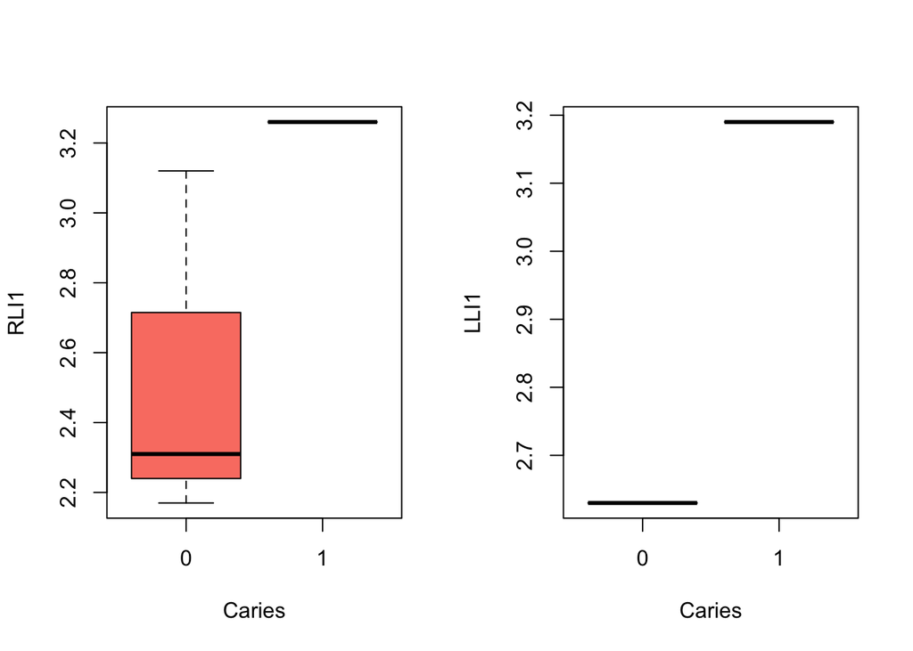

```r
par(mfrow = c(1, 2))
plot(as.factor(EW1$Caries), EW1$RLI1, xlab = "Caries", ylab = "RLI1", col = "salmon")
plot(as.factor(EW1$Caries), EW1$LLI1, xlab = "Caries", ylab = "LLI1", col = "pink")
```

```r
logistic7 <- glm(data = EW1, Caries ~ RLI1, family = "binomial")
summary(logistic7)
```

```
##
## Call:
## glm(formula = Caries ~ RLI1, family = "binomial", data = EW1)
##
## Deviance Residuals:
##         40          81          83          86
##  1.552e-05  -1.638e-05  -2.110e-08  -2.110e-08
##
## Coefficients:
##              Estimate Std. Error z value Pr(>|z|)
## (Intercept)   -1038.4  1733549.3  -0.001        1
## RLI1            325.5   543946.8   0.001        1
##
## (Dispersion parameter for binomial family taken to be 1)
##
##     Null deviance: 4.4987e+00  on 3  degrees of freedom
## Residual deviance: 5.0897e-10  on 2  degrees of freedom
##   (92 observations deleted due to missingness)
## AIC: 4
##
## Number of Fisher Scoring iterations: 25
```

```r
logistic8 <- glm(data = EW1, Caries ~ LLI1, family = "binomial")
summary(logistic8)
```

```
##
## Call:
## glm(formula = Caries ~ LLI1, family = "binomial", data = EW1)
##
## Deviance Residuals:
## [1]  0  0
##
## Coefficients:
##              Estimate Std. Error z value Pr(>|z|)
## (Intercept)   -244.92  586652.16       0        1
## LLI1            84.16  200671.88       0        1
##
## (Dispersion parameter for binomial family taken to be 1)
##
##     Null deviance: 2.7726e+00  on 1  degrees of freedom
## Residual deviance: 2.3305e-10  on 0  degrees of freedom
##   (94 observations deleted due to missingness)
## AIC: 4
##
## Number of Fisher Scoring iterations: 22
```

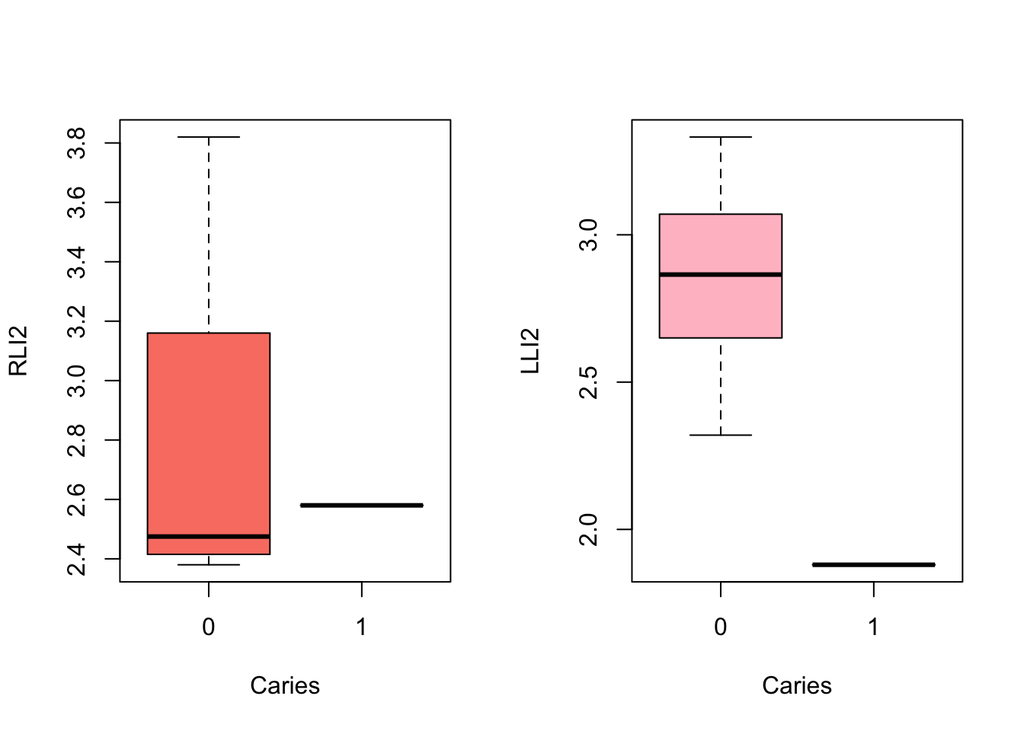

```r
par(mfrow = c(1, 2))
plot(as.factor(EW1$Caries), EW1$RLI2, xlab = "Caries", ylab = "RLI2", col = "salmon")
plot(as.factor(EW1$Caries), EW1$LLI2, xlab = "Caries", ylab = "LLI2", col = "pink")
```

```r
logistic9 <- glm(data = EW1, Caries ~ RLI2, family = "binomial")
summary(logistic9)
```

```
##
## Call:
## glm(formula = Caries ~ RLI2, family = "binomial", data = EW1)
##
## Deviance Residuals:
##      36       40       58       83       86
## -0.4056   1.7571  -0.7164  -0.7312  -0.7523
##
## Coefficients:
##             Estimate Std. Error z value Pr(>|z|)
## (Intercept)    1.096      7.497   0.146    0.884
## RLI2          -0.930      2.850  -0.326    0.744
##
## (Dispersion parameter for binomial family taken to be 1)
##
##     Null deviance: 5.0040  on 4  degrees of freedom
## Residual deviance: 4.8659  on 3  degrees of freedom
##   (91 observations deleted due to missingness)
## AIC: 8.8659
##
## Number of Fisher Scoring iterations: 5
```

```r
logistic10 <- glm(data = EW1, Caries ~ LLI2, family = "binomial")
summary(logistic10)
```

```
##
## Call:
## glm(formula = Caries ~ LLI2, family = "binomial", data = EW1)
##
## Deviance Residuals:
##         40          43          45          46          81          83
##  9.919e-06  -2.110e-08  -2.110e-08  -2.110e-08  -2.110e-08  -1.293e-05
##         84
## -2.110e-08
##
## Coefficients:
##             Estimate Std. Error z value Pr(>|z|)
## (Intercept)    224.3   536841.4       0        1
## LLI2          -106.7   247679.5       0        1
##
## (Dispersion parameter for binomial family taken to be 1)
##
##     Null deviance: 5.7416e+00  on 6  degrees of freedom
## Residual deviance: 2.6566e-10  on 5  degrees of freedom
##   (89 observations deleted due to missingness)
## AIC: 4
##
## Number of Fisher Scoring iterations: 25
```

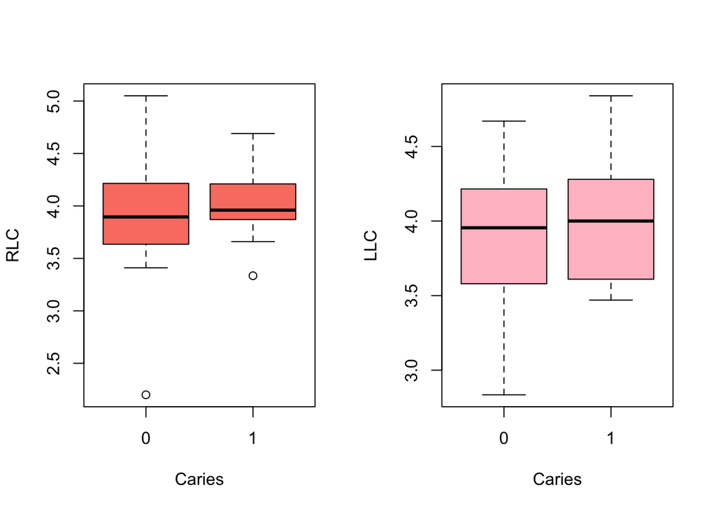

```r
par(mfrow = c(1, 2))
plot(as.factor(EW1$Caries), EW1$RLC, xlab = "Caries", ylab = "RLC", col = "salmon")
plot(as.factor(EW1$Caries), EW1$LLC, xlab = "Caries", ylab = "LLC", col = "pink")
```

```r
logistic11 <- glm(data = EW1, Caries ~ RLC, family = "binomial")
summary(logistic11)
```

```
##
## Call:
## glm(formula = Caries ~ RLC, family = "binomial", data = EW1)
##
## Deviance Residuals:
##     Min       1Q   Median       3Q      Max
## -0.9973  -0.8726  -0.8239   1.4836   1.6256
##
## Coefficients:
##             Estimate Std. Error z value Pr(>|z|)
## (Intercept)  -2.1221     2.7686  -0.766    0.443
## RLC           0.3332     0.6878   0.484    0.628
##
## (Dispersion parameter for binomial family taken to be 1)
##
##     Null deviance: 55.799  on 44  degrees of freedom
## Residual deviance: 55.559  on 43  degrees of freedom
##   (51 observations deleted due to missingness)
## AIC: 59.559
##
## Number of Fisher Scoring iterations: 4
```

```r
logistic12 <- glm(data = EW1, Caries ~ LLC, family = "binomial")
summary(logistic12)
```

```
##
## Call:
## glm(formula = Caries ~ LLC, family = "binomial", data = EW1)
##
## Deviance Residuals:
##     Min       1Q   Median       3Q      Max
## -0.9290  -0.7574  -0.6316  -0.4953   1.9306
##
## Coefficients:
##             Estimate Std. Error z value Pr(>|z|)
## (Intercept)  -4.8121     3.5944  -1.339    0.181
## LLC           0.8983     0.8951   1.004    0.316
##
## (Dispersion parameter for binomial family taken to be 1)
##
##     Null deviance: 43.156  on 40  degrees of freedom
## Residual deviance: 42.090  on 39  degrees of freedom
##   (55 observations deleted due to missingness)
## AIC: 46.09
##
## Number of Fisher Scoring iterations: 4
```

```r
library(dplyr)
M <- filter(TD1, Site=="Morhiss")
M1 <- filter(M, LEH=="1")

par(mfrow = c(1, 2))
attach(M1)
```

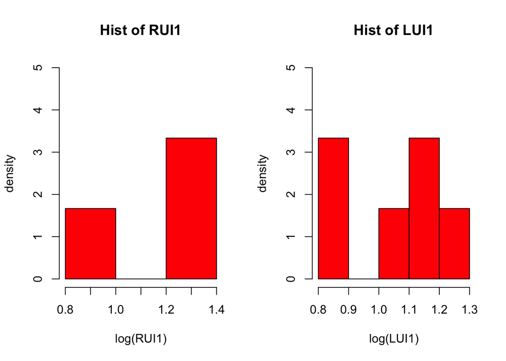

```r
hist(log(RUI1), freq = FALSE, col = "red", main = "Hist of RUI1", xlab = "log(RUI1)",
     ylab = "density", ylim = c(0, 5))


hist(log(LUI1), freq = FALSE, col = "red", main = "Hist of LUI1", xlab = "log(LUI1)",
     ylab = "density", ylim = c(0, 5))
```

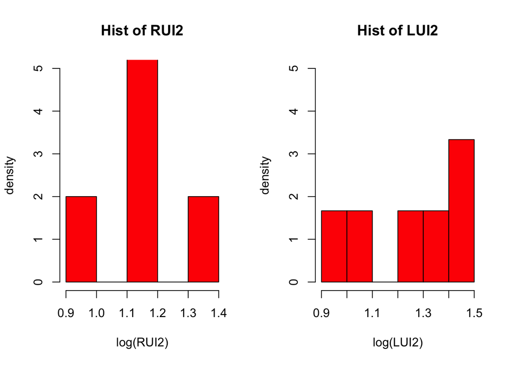

```r
hist(log(RUI2), freq = FALSE, col = "red", main = "Hist of RUI2", xlab = "log(RUI2)",
     ylab = "density", ylim = c(0, 5))


hist(log(LUI2), freq = FALSE, col = "red", main = "Hist of LUI2", xlab = "log(LUI2)",
     ylab = "density", ylim = c(0, 5))
```

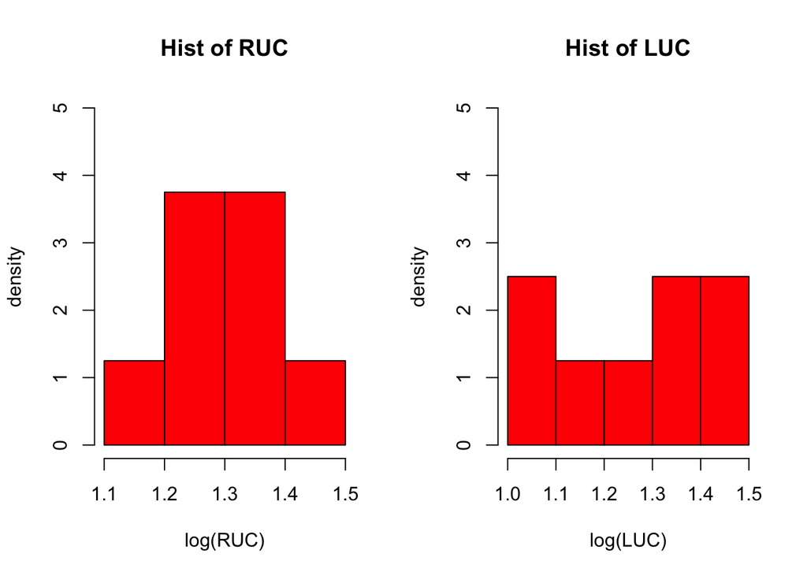

```r
hist(log(RUC), freq = FALSE, col = "red", main = "Hist of RUC", xlab = "log(RUC)",
     ylab = "density", ylim = c(0, 5))


hist(log(LUC), freq = FALSE, col = "red", main = "Hist of LUC", xlab = "log(LUC)",
     ylab = "density", ylim = c(0, 5))
```

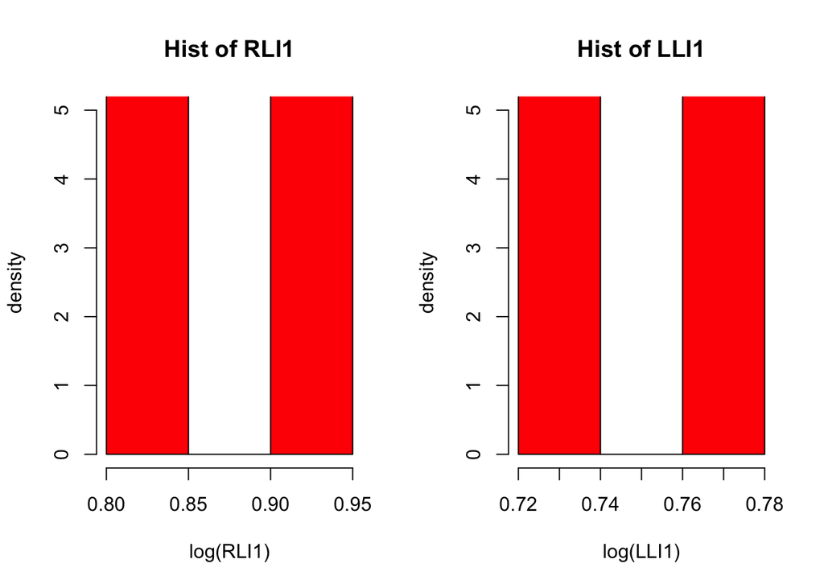

```r
hist(log(RLI1), freq = FALSE, col = "red", main = "Hist of RLI1", xlab = "log(RLI1)",
     ylab = "density", ylim = c(0, 5))


hist(log(LLI1), freq = FALSE, col = "red", main = "Hist of LLI1", xlab = "log(LLI1)",
     ylab = "density", ylim = c(0, 5))
```

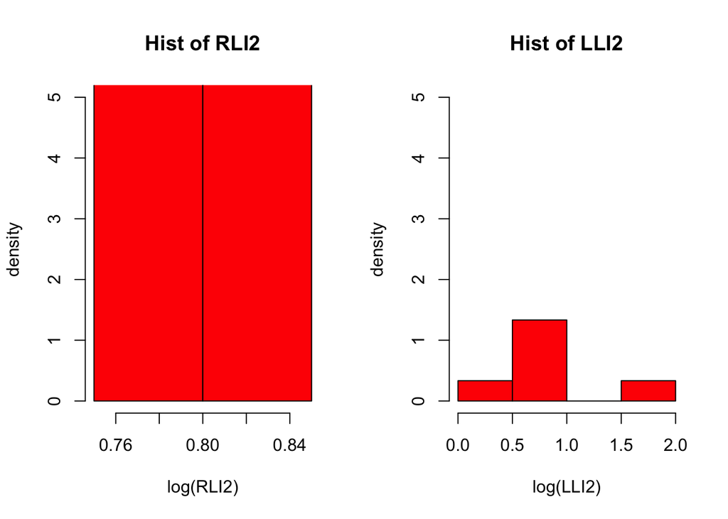

```r
hist(log(RLI2), freq = FALSE, col = "red", main = "Hist of RLI2", xlab = "log(RLI2)",
     ylab = "density", ylim = c(0, 5))


hist(log(LLI2), freq = FALSE, col = "red", main = "Hist of LLI2", xlab = "log(LLI2)",
     ylab = "density", ylim = c(0, 5))
```

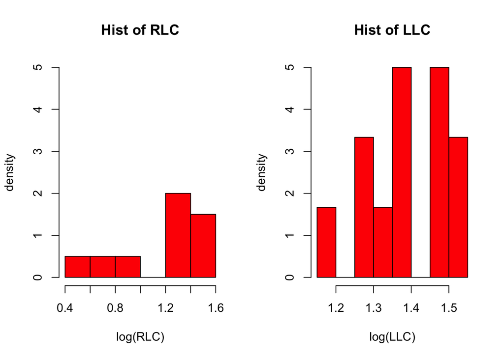

```r
hist(log(RLC), freq = FALSE, col = "red", main = "Hist of RLC", xlab = "log(RLC)",
     ylab = "density", ylim = c(0, 5))



hist(log(LLC), freq = FALSE, col = "red", main = "Hist of LLC", xlab = "log(LLC)",
     ylab = "density", ylim = c(0, 5))
```

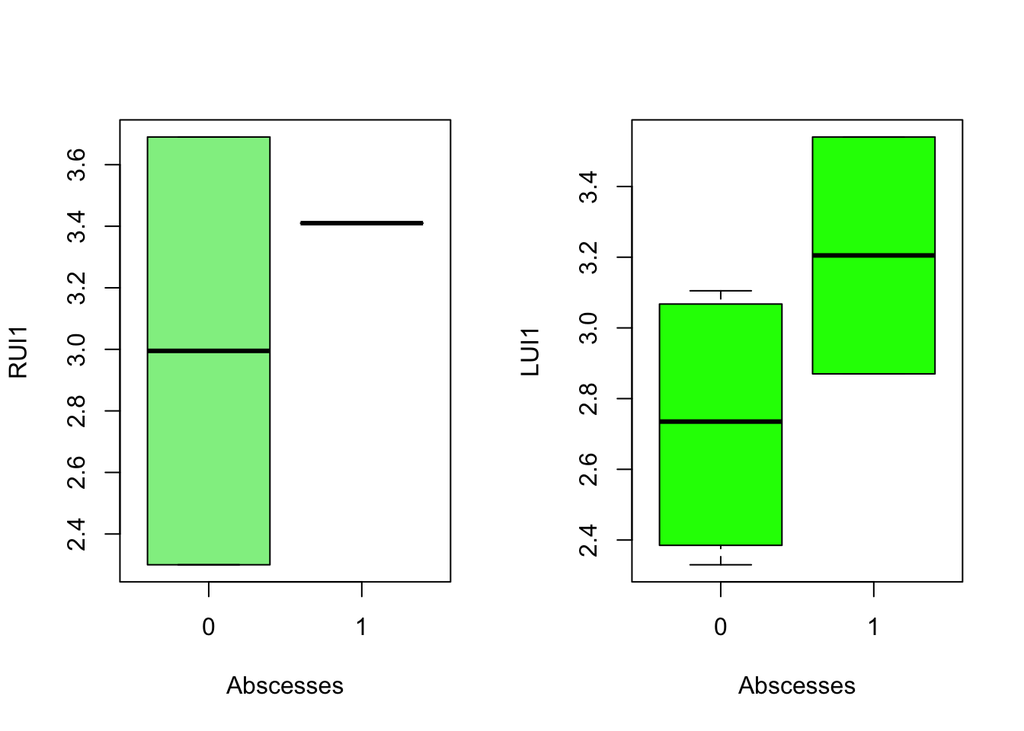

```r
library(dplyr)
M <- filter(TD1, Site=="Morhiss")
M1 <- filter(M, LEH=="1")


par(mfrow = c(1, 2))
plot(as.factor(M1$Abscesses), M1$RUI1, xlab = "Abscesses", ylab = "RUI1", col = "lightgreen")
plot(as.factor(M1$Abscesses), M1$LUI1, xlab = "Abscesses", ylab = "LUI1", col = "green")
```

```r
glm1 <- glm(data = M1, Abscesses ~ RUI1, family = "binomial")
summary(glm1)
```

```
##
## Call:
## glm(formula = Abscesses ~ RUI1, family = "binomial", data = M1)
##
## Deviance Residuals:
##       2       16       17
##  1.3696  -0.5114  -1.1537
##
## Coefficients:
##             Estimate Std. Error z value Pr(>|z|)
## (Intercept)   -5.132      8.744  -0.587    0.557
## RUI1           1.376      2.599   0.529    0.597
##
## (Dispersion parameter for binomial family taken to be 1)
##
##     Null deviance: 3.8191  on 2  degrees of freedom
## Residual deviance: 3.4684  on 1  degrees of freedom
##   (26 observations deleted due to missingness)
## AIC: 7.4684
##
## Number of Fisher Scoring iterations: 4
```

```r
glm2 <- glm(data = M1, Abscesses ~ LUI1, family = "binomial")
summary(glm2)
```

```
##
## Call:
## glm(formula = Abscesses ~ LUI1, family = "binomial", data = M1)
##
## Deviance Residuals:
##       2        4       10       11       20       23
##  0.6327  -1.0986  -0.3469  -0.2815   1.6676  -0.9813
##
## Coefficients:
##             Estimate Std. Error z value Pr(>|z|)
## (Intercept)  -12.290     10.642  -1.155    0.248
## LUI1           3.897      3.488   1.117    0.264
##
## (Dispersion parameter for binomial family taken to be 1)
##
##     Null deviance: 7.6382  on 5  degrees of freedom
## Residual deviance: 5.5505  on 4  degrees of freedom
##   (23 observations deleted due to missingness)
## AIC: 9.5505
##
## Number of Fisher Scoring iterations: 5
```

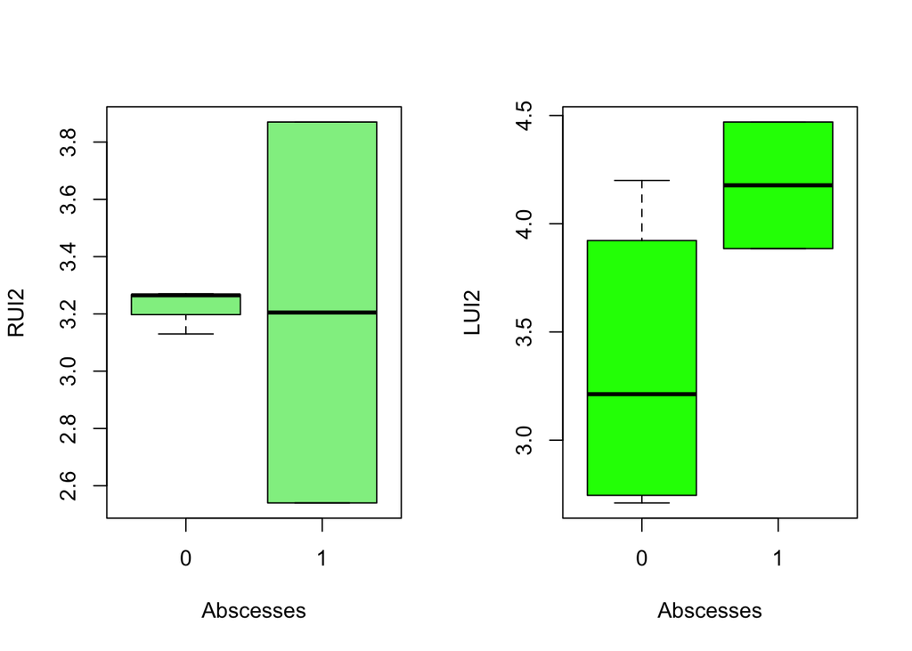

```r
par(mfrow = c(1, 2))
plot(as.factor(M1$Abscesses), M1$RUI2, xlab = "Abscesses", ylab = "RUI2", col = "lightgreen")
plot(as.factor(M1$Abscesses), M1$LUI2, xlab = "Abscesses", ylab = "LUI2", col = "green")
```

```r
glm3 <- glm(data = M1, Abscesses ~ RUI2, family = "binomial")
summary(glm3)
```

```
##
## Call:
## glm(formula = Abscesses ~ RUI2, family = "binomial", data = M1)
##
## Deviance Residuals:
##     15      18      19      20      21
## -1.009  -1.009  -1.014   1.381   1.326
##
## Coefficients:
##             Estimate Std. Error z value Pr(>|z|)
## (Intercept) -0.10706    6.98166  -0.015    0.988
## RUI2        -0.09286    2.15517  -0.043    0.966
##
## (Dispersion parameter for binomial family taken to be 1)
##
##     Null deviance: 6.7301  on 4  degrees of freedom
## Residual deviance: 6.7283  on 3  degrees of freedom
##   (24 observations deleted due to missingness)
## AIC: 10.728
##
## Number of Fisher Scoring iterations: 4
```

```r
glm4 <- glm(data = M1, Abscesses ~ LUI2, family = "binomial")
summary(glm4)
```

```
##
## Call:
## glm(formula = Abscesses ~ LUI2, family = "binomial", data = M1)
##
## Deviance Residuals:
##       2       10       12       19       20       25
##  0.6709  -0.1666  -1.3844  -0.6699   1.4307  -0.1483
##
## Coefficients:
##             Estimate Std. Error z value Pr(>|z|)
## (Intercept)  -13.562     12.346  -1.098    0.272
## LUI2           3.342      3.066   1.090    0.276
##
## (Dispersion parameter for binomial family taken to be 1)
##
##     Null deviance: 7.6382  on 5  degrees of freedom
## Residual deviance: 4.9120  on 4  degrees of freedom
##   (23 observations deleted due to missingness)
## AIC: 8.912
##
## Number of Fisher Scoring iterations: 6
```

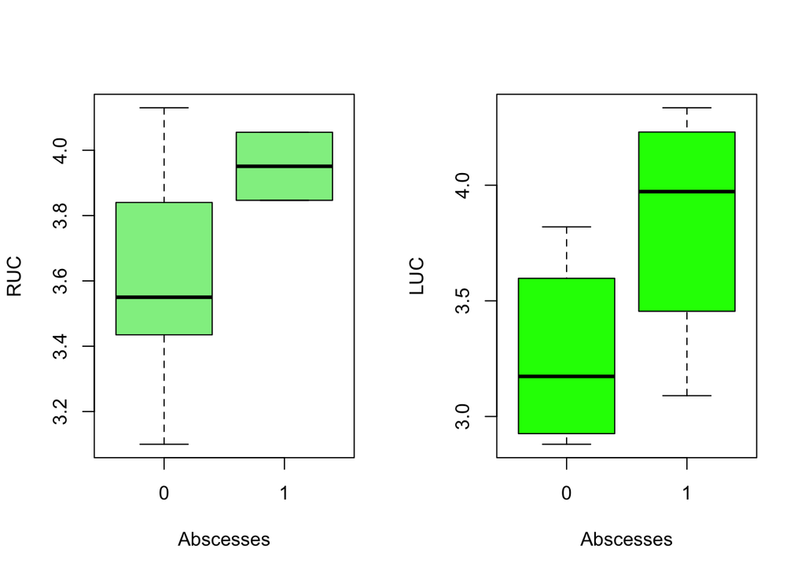

```r
par(mfrow = c(1, 2))
plot(as.factor(M1$Abscesses), M1$RUC, xlab = "Abscesses", ylab = "RUC", col = "lightgreen")
plot(as.factor(M1$Abscesses), M1$LUC, xlab = "Abscesses", ylab = "LUC", col = "green")
```

```r
glm5 <- glm(data = M1, Abscesses ~ RUC, family = "binomial")
summary(glm5)
```

```
##
## Call:
## glm(formula = Abscesses ~ RUC, family = "binomial", data = M1)
##
## Deviance Residuals:
##     Min       1Q   Median       3Q      Max
## -1.4019  -0.6131  -0.3343   0.1695   1.5644
##
## Coefficients:
##             Estimate Std. Error z value Pr(>|z|)
## (Intercept)  -19.735     16.585  -1.190    0.234
## RUC            4.903      4.261   1.151    0.250
##
## (Dispersion parameter for binomial family taken to be 1)
##
##     Null deviance: 8.9974  on 7  degrees of freedom
## Residual deviance: 6.8758  on 6  degrees of freedom
##   (21 observations deleted due to missingness)
## AIC: 10.876
##
## Number of Fisher Scoring iterations: 5
```

```r
glm6 <- glm(data = M1, Abscesses ~ LUC, family = "binomial")
summary(glm6)
```

```
##
## Call:
## glm(formula = Abscesses ~ LUC, family = "binomial", data = M1)
##
## Deviance Residuals:
##      Min        1Q    Median        3Q       Max
## -1.49987  -0.71364  -0.03907   0.68672   1.72279
##
## Coefficients:
##             Estimate Std. Error z value Pr(>|z|)
## (Intercept)   -9.519      6.670  -1.427    0.154
## LUC            2.684      1.868   1.437    0.151
##
## (Dispersion parameter for binomial family taken to be 1)
##
##     Null deviance: 11.0904  on 7  degrees of freedom
## Residual deviance:  8.2883  on 6  degrees of freedom
##   (21 observations deleted due to missingness)
## AIC: 12.288
##
## Number of Fisher Scoring iterations: 3
```

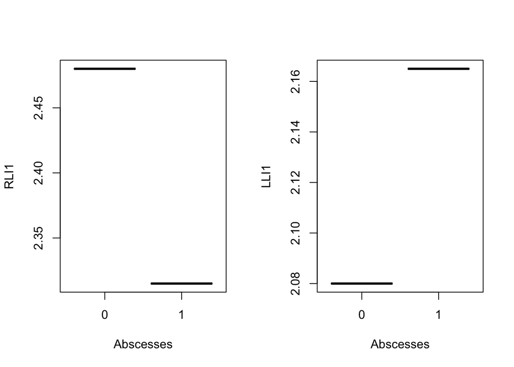

```r
par(mfrow = c(1, 2))
plot(as.factor(M1$Abscesses), M1$RLI1, xlab = "Abscesses", ylab = "RLI1", col = "lightgreen")
plot(as.factor(M1$Abscesses), M1$LLI1, xlab = "Abscesses", ylab = "LLI1", col = "green")
```

```r
glm7 <- glm(data = M1, Abscesses ~ RLI1, family = "binomial")
summary(glm7)
```

```
##
## Call:
## glm(formula = Abscesses ~ RLI1, family = "binomial", data = M1)
##
## Deviance Residuals:
## [1]  0  0
##
## Coefficients:
##              Estimate Std. Error z value Pr(>|z|)
## (Intercept)     684.8  1633827.5       0        1
## RLI1           -285.6   681068.2       0        1
##
## (Dispersion parameter for binomial family taken to be 1)
##
##     Null deviance: 2.7726e+00  on 1  degrees of freedom
## Residual deviance: 2.3305e-10  on 0  degrees of freedom
##   (27 observations deleted due to missingness)
## AIC: 4
##
## Number of Fisher Scoring iterations: 22
```

```r
glm8 <- glm(data = M1, Abscesses ~ LLI1, family = "binomial")
summary(glm8)
```

```
##
## Call:
## glm(formula = Abscesses ~ LLI1, family = "binomial", data = M1)
##
## Deviance Residuals:
## [1]  0  0
##
## Coefficients:
##              Estimate Std. Error z value Pr(>|z|)
## (Intercept)   -1176.9  2806663.3       0        1
## LLI1            554.5  1322073.4       0        1
##
## (Dispersion parameter for binomial family taken to be 1)
##
##     Null deviance: 2.7726e+00  on 1  degrees of freedom
## Residual deviance: 2.3305e-10  on 0  degrees of freedom
##   (27 observations deleted due to missingness)
## AIC: 4
##
## Number of Fisher Scoring iterations: 22
```

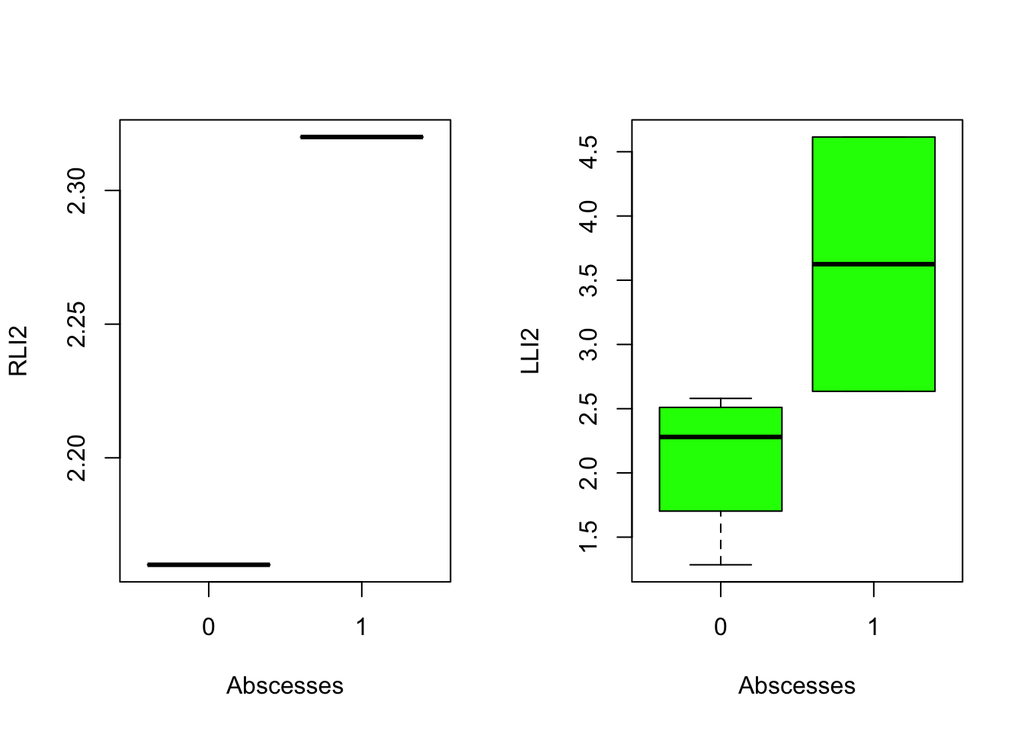

```r
par(mfrow = c(1, 2))
plot(as.factor(M1$Abscesses), M1$RLI2, xlab = "Abscesses", ylab = "RLI2", col = "lightgreen")
plot(as.factor(M1$Abscesses), M1$LLI2, xlab = "Abscesses", ylab = "LLI2", col = "green")
```

```r
glm9 <- glm(data = M1, Abscesses ~ RLI2, family = "binomial")
summary(glm9)
```

```
##
## Call:
## glm(formula = Abscesses ~ RLI2, family = "binomial", data = M1)
##
## Deviance Residuals:
## [1]  0  0
##
## Coefficients:
##              Estimate Std. Error z value Pr(>|z|)
## (Intercept)    -659.8  1574270.6       0        1
## RLI2            294.6   702351.6       0        1
##
## (Dispersion parameter for binomial family taken to be 1)
##
##     Null deviance: 2.7726e+00  on 1  degrees of freedom
## Residual deviance: 2.3305e-10  on 0  degrees of freedom
##   (27 observations deleted due to missingness)
## AIC: 4
##
## Number of Fisher Scoring iterations: 22
```

```r
glm10 <- glm(data = M1, Abscesses ~ LLI2, family = "binomial")
summary(glm10)
```

```
##
## Call:
## glm(formula = Abscesses ~ LLI2, family = "binomial", data = M1)
##
## Deviance Residuals:
##          8          10          17          20          21          25
## -2.100e-08  -2.100e-08  -5.771e-05   5.139e-05   2.100e-08  -2.100e-08
##
## Coefficients:
##              Estimate Std. Error z value Pr(>|z|)
## (Intercept)   -1927.5  1058326.5  -0.002    0.999
## LLI2            739.2   406350.7   0.002    0.999
##
## (Dispersion parameter for binomial family taken to be 1)
##
##     Null deviance: 7.6382e+00  on 5  degrees of freedom
## Residual deviance: 5.9718e-09  on 4  degrees of freedom
##   (23 observations deleted due to missingness)
## AIC: 4
##
## Number of Fisher Scoring iterations: 25
```

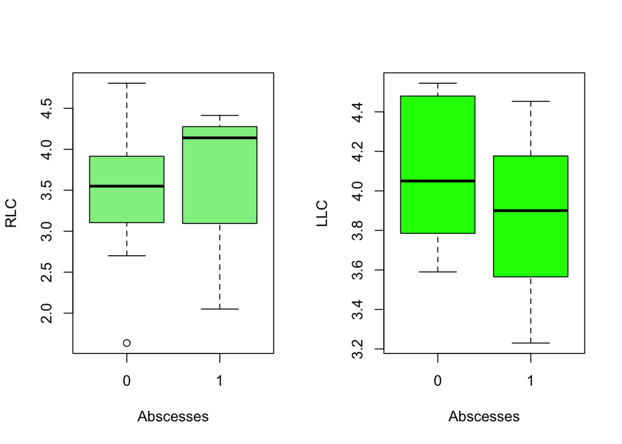

```r
par(mfrow = c(1, 2))
plot(as.factor(M1$Abscesses), M1$RLC, xlab = "Abscesses", ylab = "RLC", col = "lightgreen")
plot(as.factor(M1$Abscesses), M1$LLC, xlab = "Abscesses", ylab = "LLC", col = "green")
```

```r
glm11 <- glm(data = M1, Abscesses ~ RLC, family = "binomial")
summary(glm11)
```

```
##
## Call:
## glm(formula = Abscesses ~ RLC, family = "binomial", data = M1)
##
## Deviance Residuals:
##     Min       1Q   Median       3Q      Max
## -0.8964  -0.8570  -0.8302   0.9359   1.6218
##
## Coefficients:
##             Estimate Std. Error z value Pr(>|z|)
## (Intercept)  -1.2243     2.6135  -0.468    0.639
## RLC           0.1082     0.7190   0.150    0.880
##
## (Dispersion parameter for binomial family taken to be 1)
##
##     Null deviance: 12.217  on 9  degrees of freedom
## Residual deviance: 12.194  on 8  degrees of freedom
##   (19 observations deleted due to missingness)
## AIC: 16.194
##
## Number of Fisher Scoring iterations: 4
```

```r
glm12 <- glm(data = M1, Abscesses ~ LLC, family = "binomial")
summary(glm12)
```

```
##
## Call:
## glm(formula = Abscesses ~ LLC, family = "binomial", data = M1)
##
## Deviance Residuals:
##      Min        1Q    Median        3Q       Max
## -0.95414  -0.77219  -0.59378  -0.09883   1.95896
##
## Coefficients:
##             Estimate Std. Error z value Pr(>|z|)
## (Intercept)    4.477      6.638   0.675    0.500
## LLC           -1.401      1.681  -0.833    0.405
##
## (Dispersion parameter for binomial family taken to be 1)
##
##     Null deviance: 13.496  on 11  degrees of freedom
## Residual deviance: 12.762  on 10  degrees of freedom
##   (17 observations deleted due to missingness)
## AIC: 16.762
##
## Number of Fisher Scoring iterations: 4
```

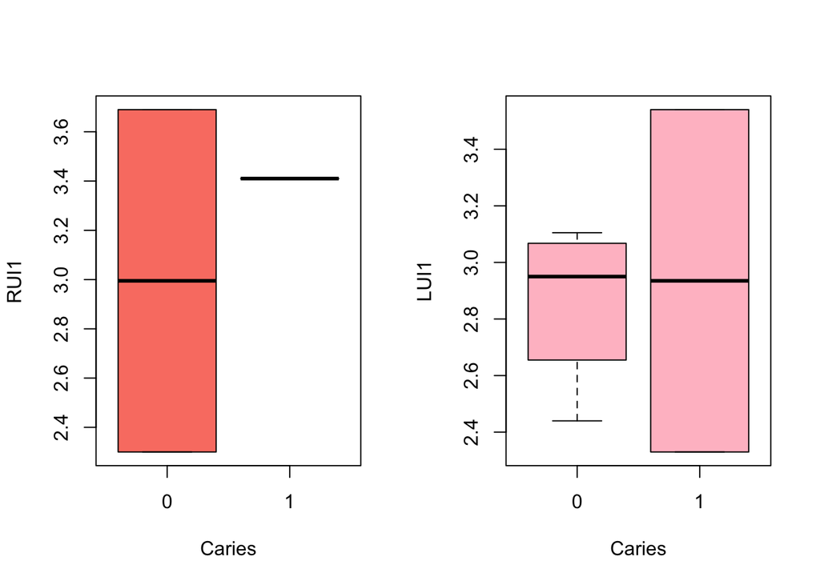

```r
library(dplyr)
M <- filter(TD1, Site=="Morhiss")
M1 <- filter(M, LEH=="1")


par(mfrow = c(1, 2))
plot(as.factor(M1$Caries), M1$RUI1, xlab = "Caries", ylab = "RUI1", col = "salmon")
plot(as.factor(M1$Caries), M1$LUI1, xlab = "Caries", ylab = "LUI1", col = "pink")
```

```r
glm1 <- glm(data = M1, Caries ~ RUI1, family = "binomial")
summary(glm1)
```

```
##
## Call:
## glm(formula = Caries ~ RUI1, family = "binomial", data = M1)
##
## Deviance Residuals:
##       2       16       17
##  1.3696  -0.5114  -1.1537
##
## Coefficients:
##             Estimate Std. Error z value Pr(>|z|)
## (Intercept)   -5.132      8.744  -0.587    0.557
## RUI1           1.376      2.599   0.529    0.597
##
## (Dispersion parameter for binomial family taken to be 1)
##
##     Null deviance: 3.8191  on 2  degrees of freedom
## Residual deviance: 3.4684  on 1  degrees of freedom
##   (26 observations deleted due to missingness)
## AIC: 7.4684
##
## Number of Fisher Scoring iterations: 4
```

```r
glm2 <- glm(data = M1, Caries ~ LUI1, family = "binomial")
summary(glm2)
```

```
##
## Call:
## glm(formula = Caries ~ LUI1, family = "binomial", data = M1)
##
## Deviance Residuals:
##       2        4       10       11       20       23
##  1.3556  -0.9347  -0.8276   1.5954  -0.8959  -0.9223
##
## Coefficients:
##             Estimate Std. Error z value Pr(>|z|)
## (Intercept)  -1.9732     6.2540  -0.316    0.752
## LUI1          0.4417     2.1282   0.208    0.836
##
## (Dispersion parameter for binomial family taken to be 1)
##
##     Null deviance: 7.6382  on 5  degrees of freedom
## Residual deviance: 7.5948  on 4  degrees of freedom
##   (23 observations deleted due to missingness)
## AIC: 11.595
##
## Number of Fisher Scoring iterations: 4
```

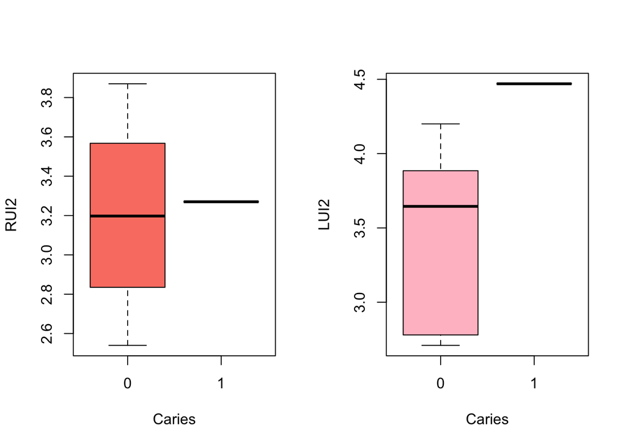

```r
par(mfrow = c(1, 2))
plot(as.factor(M1$Caries), M1$RUI2, xlab = "Caries", ylab = "RUI2", col = "salmon")
plot(as.factor(M1$Caries), M1$LUI2, xlab = "Caries", ylab = "LUI2", col = "pink")
```

```r
glm3 <- glm(data = M1, Caries ~ RUI2, family = "binomial")
summary(glm3)
```

```
##
## Call:
## glm(formula = Caries ~ RUI2, family = "binomial", data = M1)
##
## Deviance Residuals:
##      15       18       19       20       21
##  1.7882  -0.6714  -0.6559  -0.7445  -0.5914
##
## Coefficients:
##             Estimate Std. Error z value Pr(>|z|)
## (Intercept)  -2.6355     8.7517  -0.301    0.763
## RUI2          0.3861     2.6655   0.145    0.885
##
## (Dispersion parameter for binomial family taken to be 1)
##
##     Null deviance: 5.0040  on 4  degrees of freedom
## Residual deviance: 4.9829  on 3  degrees of freedom
##   (24 observations deleted due to missingness)
## AIC: 8.9829
##
## Number of Fisher Scoring iterations: 4
```